# SI 370: Homework 4: Malicious and Benign Websites

## Name: Samantha Cohen

## Uniqname: samcoh

This homework assignment uses the dataset from the "Malicious and Benign Websites" Kaggle project at https://www.kaggle.com/xwolf12/malicious-and-benign-websites/home (you'll need to go to that URL to get a full description of the data).

From the overview:

> The project consisted to evaluate different classification models to predict malicious and benign websites, based on application layer and network characteristics. The data were obtained by using different verified sources of benign and malicious URL's, in a low interactive client honeypot to isolate network traffic. We used additional tools to get other information, such as, server country with Whois.

In this assignment, you will perform three tasks, each worth 10 points (specific point allocations are provided for each task).

# First, let's load the data:

## 1) Imports

```python
import pandas as pd
from sklearn import metrics
import numpy as np
from sklearn.cluster import KMeans #KMeans from sklearn clusters
import seaborn as sns
import matplotlib.pyplot as plt
%matplotlib inline

from sklearn.manifold import TSNE


from sklearn.ensemble import RandomForestClassifier
from sklearn.metrics import accuracy_score
from sklearn.naive_bayes import GaussianNB
from sklearn.model_selection import train_test_split

from sklearn.model_selection import GridSearchCV
from sklearn.linear_model import LogisticRegression
from sklearn.metrics import accuracy_score
from sklearn.metrics import classification_report, confusion_matrix
from sklearn.tree import DecisionTreeClassifier
from sklearn.tree import export_graphviz
from sklearn.model_selection import train_test_split
from sklearn.metrics import accuracy_score
from IPython.display import Image
from sklearn.model_selection import cross_val_score
from sklearn.preprocessing import scale
```

## 2) read_csv data

```python
data = pd.read_csv('data/malicious_and_benign.csv')
```

```python
data.head(3)
```

|  | URL | URL_LENGTH | NUMBER_SPECIAL_CHARACTERS | CHARSET | SERVER | CONTENT_LENGTH | WHOIS_COUNTRY | WHOIS_STATEPRO | WHOIS_REGDATE | WHOIS_UPDATED_DATE | ... | DIST_REMOTE_TCP_PORT | REMOTE_IPS | APP_BYTES | SOURCE_APP_PACKETS | REMOTE_APP_PACKETS | SOURCE_APP_BYTES | REMOTE_APP_BYTES | APP_PACKETS | DNS_QUERY_TIMES | Type |
| --- | --- | --- | --- | --- | --- | --- | --- | --- | --- | --- | --- | --- | --- | --- | --- | --- | --- | --- | --- | --- | --- |
| 0 | M0_109 | 16 | 7 | iso-8859-1 | nginx | 263.0 | None | None | 10/10/2015 18:21 | None | ... | 0 | 2 | 700 | 9 | 10 | 1153 | 832 | 9 | 2.0 | 1 |
| 1 | B0_2314 | 16 | 6 | UTF-8 | Apache/2.4.10 | 15087.0 | None | None | None | None | ... | 7 | 4 | 1230 | 17 | 19 | 1265 | 1230 | 17 | 0.0 | 0 |
| 2 | B0_911 | 16 | 6 | us-ascii | Microsoft-HTTPAPI/2.0 | 324.0 | None | None | None | None | ... | 0 | 0 | 0 | 0 | 0 | 0 | 0 | 0 | 0.0 | 0 |

3 rows × 21 columns

```python
data.columns
```

```
Index(['URL', 'URL_LENGTH', 'NUMBER_SPECIAL_CHARACTERS', 'CHARSET', 'SERVER',
       'CONTENT_LENGTH', 'WHOIS_COUNTRY', 'WHOIS_STATEPRO', 'WHOIS_REGDATE',
       'WHOIS_UPDATED_DATE', 'TCP_CONVERSATION_EXCHANGE',
       'DIST_REMOTE_TCP_PORT', 'REMOTE_IPS', 'APP_BYTES', 'SOURCE_APP_PACKETS',
       'REMOTE_APP_PACKETS', 'SOURCE_APP_BYTES', 'REMOTE_APP_BYTES',
       'APP_PACKETS', 'DNS_QUERY_TIMES', 'Type'],
      dtype='object')
```

```python
data.shape #should not have 1781 clusters trying to reduce this down
```

```
(1781, 21)
```

# Part 1: k-means clustering

### a) Perform a K-means clustering of the websites in the dataset (7 points).

- pick the optimal value of k
- silhouette_score 1 is really good -1 is really bad
- increasing k is not necessarily better
- show visualization here

#### 1) drop null values and assign the new DataFrame to the variable data_nonulls

```python
# data_nonulls = data.dropna()
data = data.replace("None", np.nan)
data.head(5)
```

|  | URL | URL_LENGTH | NUMBER_SPECIAL_CHARACTERS | CHARSET | SERVER | CONTENT_LENGTH | WHOIS_COUNTRY | WHOIS_STATEPRO | WHOIS_REGDATE | WHOIS_UPDATED_DATE | ... | DIST_REMOTE_TCP_PORT | REMOTE_IPS | APP_BYTES | SOURCE_APP_PACKETS | REMOTE_APP_PACKETS | SOURCE_APP_BYTES | REMOTE_APP_BYTES | APP_PACKETS | DNS_QUERY_TIMES | Type |
| --- | --- | --- | --- | --- | --- | --- | --- | --- | --- | --- | --- | --- | --- | --- | --- | --- | --- | --- | --- | --- | --- |
| 0 | M0_109 | 16 | 7 | iso-8859-1 | nginx | 263.0 | NaN | NaN | 10/10/2015 18:21 | NaN | ... | 0 | 2 | 700 | 9 | 10 | 1153 | 832 | 9 | 2.0 | 1 |
| 1 | B0_2314 | 16 | 6 | UTF-8 | Apache/2.4.10 | 15087.0 | NaN | NaN | NaN | NaN | ... | 7 | 4 | 1230 | 17 | 19 | 1265 | 1230 | 17 | 0.0 | 0 |
| 2 | B0_911 | 16 | 6 | us-ascii | Microsoft-HTTPAPI/2.0 | 324.0 | NaN | NaN | NaN | NaN | ... | 0 | 0 | 0 | 0 | 0 | 0 | 0 | 0 | 0.0 | 0 |
| 3 | B0_113 | 17 | 6 | ISO-8859-1 | nginx | 162.0 | US | AK | 7/10/1997 4:00 | 12/09/2013 0:45 | ... | 22 | 3 | 3812 | 39 | 37 | 18784 | 4380 | 39 | 8.0 | 0 |
| 4 | B0_403 | 17 | 6 | UTF-8 | NaN | 124140.0 | US | TX | 12/05/1996 0:00 | 11/04/2017 0:00 | ... | 2 | 5 | 4278 | 61 | 62 | 129889 | 4586 | 61 | 4.0 | 0 |

5 rows × 21 columns

```python
data_nonulls = data.dropna()
data_nonulls.head(5)
```

|  | URL | URL_LENGTH | NUMBER_SPECIAL_CHARACTERS | CHARSET | SERVER | CONTENT_LENGTH | WHOIS_COUNTRY | WHOIS_STATEPRO | WHOIS_REGDATE | WHOIS_UPDATED_DATE | ... | DIST_REMOTE_TCP_PORT | REMOTE_IPS | APP_BYTES | SOURCE_APP_PACKETS | REMOTE_APP_PACKETS | SOURCE_APP_BYTES | REMOTE_APP_BYTES | APP_PACKETS | DNS_QUERY_TIMES | Type |
| --- | --- | --- | --- | --- | --- | --- | --- | --- | --- | --- | --- | --- | --- | --- | --- | --- | --- | --- | --- | --- | --- |
| 3 | B0_113 | 17 | 6 | ISO-8859-1 | nginx | 162.0 | US | AK | 7/10/1997 4:00 | 12/09/2013 0:45 | ... | 22 | 3 | 3812 | 39 | 37 | 18784 | 4380 | 39 | 8.0 | 0 |
| 6 | B0_462 | 18 | 6 | iso-8859-1 | Apache/2 | 345.0 | US | CO | 29/07/2002 0:00 | 1/07/2016 0:00 | ... | 0 | 3 | 1189 | 14 | 13 | 8559 | 1327 | 14 | 2.0 | 0 |
| 7 | B0_1128 | 19 | 6 | us-ascii | Microsoft-HTTPAPI/2.0 | 324.0 | US | FL | 18/03/1997 0:00 | 19/03/2017 0:00 | ... | 0 | 0 | 0 | 0 | 0 | 0 | 0 | 0 | 0.0 | 0 |
| 11 | B0_1102 | 20 | 6 | us-ascii | Microsoft-HTTPAPI/2.0 | 324.0 | US | CO | 22/11/2016 0:00 | 23/11/2016 0:00 | ... | 0 | 0 | 0 | 0 | 0 | 0 | 0 | 0 | 0.0 | 0 |
| 16 | M0_97 | 21 | 7 | iso-8859-1 | nginx | 686.0 | RU | Novosibirskaya obl. | 25/05/2013 0:00 | 23/05/2016 0:00 | ... | 0 | 2 | 603 | 8 | 9 | 1580 | 745 | 8 | 2.0 | 1 |

5 rows × 21 columns

```python
data_nonulls.columns
```

```
Index(['URL', 'URL_LENGTH', 'NUMBER_SPECIAL_CHARACTERS', 'CHARSET', 'SERVER',
       'CONTENT_LENGTH', 'WHOIS_COUNTRY', 'WHOIS_STATEPRO', 'WHOIS_REGDATE',
       'WHOIS_UPDATED_DATE', 'TCP_CONVERSATION_EXCHANGE',
       'DIST_REMOTE_TCP_PORT', 'REMOTE_IPS', 'APP_BYTES', 'SOURCE_APP_PACKETS',
       'REMOTE_APP_PACKETS', 'SOURCE_APP_BYTES', 'REMOTE_APP_BYTES',
       'APP_PACKETS', 'DNS_QUERY_TIMES', 'Type'],
      dtype='object')
```

```python
data_nonulls = data_nonulls.copy()
```

##### Explanation:

First, did .replace to replace all None values with NULL. Afterwards, I used dropna to drop all null values in the DataFrame. I assigned this new DataFrame to the variable data_nonulls. I dropped all the null values because, as we learned in class, when we perform clustering the algorithms do not like null values; therefore, I want to drop all rows that have null values in the DataFrame.

#### 2) Separate the datetime columns in the DataFrame,WHOIS_UPDATED_DATE and WHOIS_REGDATE.

```python
data_nonulls['WHOIS_UPDATED_DATE_YEAR'] = pd.to_datetime(data_nonulls['WHOIS_UPDATED_DATE']).apply(lambda x: int(x.year))
data_nonulls['WHOIS_UPDATED_DATE_DAY'] =  pd.to_datetime(data_nonulls['WHOIS_UPDATED_DATE']).apply(lambda x: int(x.day))
data_nonulls['WHOIS_UPDATED_DATE_MONTH'] =  pd.to_datetime(data_nonulls['WHOIS_UPDATED_DATE']).apply(lambda x: int(x.month))

data_nonulls['WHOIS_REGDATE_YEAR'] = pd.to_datetime(data_nonulls['WHOIS_REGDATE']).apply(lambda x: int(x.year))
data_nonulls['WHOIS_REGDATE_DAY'] = pd.to_datetime(data_nonulls['WHOIS_REGDATE']).apply(lambda x: int(x.day))
data_nonulls['WHOIS_REGDATE_MONTH'] = pd.to_datetime(data_nonulls['WHOIS_REGDATE']).apply(lambda x: int(x.month))
```

```python
data_nonulls = data_nonulls.drop(columns = ["WHOIS_UPDATED_DATE","WHOIS_REGDATE"])
```

##### Explanation:

I added six new columns to the DataFrame: WHOIS_UPDATED_DATE_YEAR, WHOIS_UPDATED_DATE_DAY, WHOIS_UPDATED_DATE_MONTH, WHOIS_REGDATE_YEAR, WHOIS_REGDATE_DAY, WHOIS_REGDATE_MONTH. Each of the columns has either just the year, day or month of the original datetime. The type of these colums is an integer. Afterwards, I dropped the columns "WHOIS_UPDATED_DATE" and "WHOIS_REGDATE" from the data_nonulls DataFrame so it would not throw an error when doing k_means.

```python
data_nonulls_drop_dates= data_nonulls.drop(columns = ['WHOIS_UPDATED_DATE_YEAR',
                             'WHOIS_UPDATED_DATE_DAY',
                            'WHOIS_UPDATED_DATE_MONTH',
                            'WHOIS_REGDATE_YEAR',
                             'WHOIS_REGDATE_DAY',
                             'WHOIS_REGDATE_MONTH'
                            ])
```

##### Explanation:

I ended up dropping the date columns I created above: 'WHOIS_UPDATED_DATE_YEAR','WHOIS_UPDATED_DATE_DAY','WHOIS_UPDATED_DATE_MONTH','WHOIS_REGDATE_YEAR','WHOIS_REGDATE_DAY', and 'WHOIS_REGDATE_MONTH'. When I calculated the k-mean with these data columns it appeared to skew my results. I assigned the resulting DataFrame to data_nonulls_drop_dates.

#### 3) I found the numerical data columns by using .describe. I then filtered the DataFrame to only include the columns from .describe. This is because .describe only performed computations on the numerical columns. Afterwards, I assigned the resulting dataframe to the variable data_nonulls_only_numerical. I then scaled this dataframe to prevent the results from being skewed.

```python
only_numerical = data_nonulls_drop_dates.describe().columns
data_nonulls_only_numerical_not_scaled = data_nonulls_drop_dates[list(only_numerical)]
```

```python
data_nonulls_only_numerical_not_scaled_type = data_nonulls_only_numerical_not_scaled["Type"]
data_nonulls_only_numerical_not_scaled_no_type = data_nonulls_only_numerical_not_scaled.drop('Type',axis=1)

#data_nonulls_only_numerical = pd.DataFrame(scale(data_nonulls_only_numerical_not_scaled), columns = list(data_nonulls_only_numerical_not_scaled.columns))
data_nonulls_only_numerical = pd.DataFrame(scale(data_nonulls_only_numerical_not_scaled_no_type), columns = list(data_nonulls_only_numerical_not_scaled_no_type.columns))
#data_nonulls_only_numerical = data_nonulls_only_numerical_not_scaled_no_type.copy()
```

```python
data_nonulls_only_numerical.head()
```

|  | URL_LENGTH | NUMBER_SPECIAL_CHARACTERS | CONTENT_LENGTH | TCP_CONVERSATION_EXCHANGE | DIST_REMOTE_TCP_PORT | REMOTE_IPS | APP_BYTES | SOURCE_APP_PACKETS | REMOTE_APP_PACKETS | SOURCE_APP_BYTES | REMOTE_APP_BYTES | APP_PACKETS | DNS_QUERY_TIMES |
| --- | --- | --- | --- | --- | --- | --- | --- | --- | --- | --- | --- | --- | --- |
| 0 | -1.550809 | -1.163403 | -0.447463 | 0.260262 | 2.778316 | 0.004083 | 0.461302 | 0.367052 | 0.294845 | -0.007965 | 0.541786 | 0.367052 | 2.280517 |
| 1 | -1.511786 | -1.163403 | -0.440290 | -0.099991 | -0.481028 | 0.004083 | -0.118317 | -0.100137 | -0.117101 | -0.116960 | -0.121674 | -0.100137 | -0.029051 |
| 2 | -1.472762 | -1.163403 | -0.441113 | -0.327519 | -0.481028 | -0.861553 | -0.381056 | -0.361763 | -0.340239 | -0.208195 | -0.410049 | -0.361763 | -0.798907 |
| 3 | -1.433739 | -1.163403 | -0.441113 | -0.327519 | -0.481028 | -0.861553 | -0.381056 | -0.361763 | -0.340239 | -0.208195 | -0.410049 | -0.361763 | -0.798907 |
| 4 | -1.394716 | -0.920566 | -0.426924 | -0.213755 | -0.481028 | -0.284462 | -0.247808 | -0.212263 | -0.185759 | -0.191353 | -0.248150 | -0.212263 | -0.029051 |

##### Explanation:

I want to only include numerical columns so I can use the KMeans algorithm. I found the numerical columns in the DataFrame by using .describe and using the returned columns in the DataFrame. Then, I filtered the DataFrame to only include numerical columns and assigned the DataFrame to the variable data_nonulls_only_numerical_not_scaled.

After, I assigned the variable data_nonulls_only_numerical_not_scaled_no_type to the DataFrame with all columns in data_nonulls_only_numerical_not_scaled besides the Type column. The Type column is a categorical column so it should not be included in clustering. Only numerical columns should be included.

I also assigned the variable data_nonulls_only_numerical_not_scaled_type to the series data_nonulls_only_numerical_not_scaled["Type"]. I did this so I can refer to this Type column later.

Afterwards, I scaled the DataFrame using data_nonulls_only_numerical_not_scaled_no_type, which is the DataFrame without the Type column. By scaling the DataFrame in the beginning, I will prevent errors later on. I assigned the scaled DataFrame to the variable data_nonulls_only_numerical.

Another reason why scaling is good to use here is because the ranges for the values of each column were very different; therefore, using scaled data will prevent skewed results. The scaled DataFrame will be used when performing a k-means clustering in the code below.

#### 4) Perform a K-means clustering of the websites in the dataset for any k value, and find the silhouette score. (1 pt)

```python
kmeans = KMeans(n_clusters=4) # start with 3 clusters
kmeans.fit(data_nonulls_only_numerical)
print("Labels:")
print(kmeans.labels_)
```

```
Labels:
[2 0 0 0 0 0 0 0 0 0 0 0 2 0 0 2 2 0 0 0 0 2 0 0 0 0 0 0 2 2 0 0 0 0 0 0 2
 0 2 2 2 0 2 0 0 0 0 0 0 0 0 0 0 2 2 2 0 0 0 0 2 2 2 0 0 0 0 0 2 2 2 0 0 0
 0 0 0 2 2 2 0 0 0 0 2 0 0 2 0 0 2 0 0 2 0 0 2 2 2 2 0 0 0 0 0 2 0 0 0 0 0
 0 0 0 0 0 0 0 0 0 0 2 2 2 0 0 0 2 2 0 0 0 0 0 0 0 2 2 0 2 2 2 2 0 0 2 0 0
 0 0 0 0 0 0 2 0 2 2 2 0 0 0 2 0 0 0 0 0 0 0 0 0 2 0 0 0 0 2 2 2 2 0 0 2 0
 0 0 0 0 0 0 0 2 2 2 2 2 0 0 0 0 0 2 0 2 2 0 0 0 2 0 0 0 0 2 2 2 0 2 0 0 0
 0 0 2 2 2 0 2 2 2 0 0 0 0 0 0 0 0 0 0 2 0 0 2 0 2 2 0 0 2 0 0 0 0 2 2 0 0
 2 0 2 2 2 2 2 2 2 2 0 0 0 0 0 2 2 0 0 2 2 0 0 0 0 0 0 0 2 0 2 2 2 0 0 0 0
 0 0 0 0 0 0 0 2 0 2 0 2 2 2 0 0 0 0 0 0 2 2 0 2 0 0 0 0 0 0 0 0 0 0 0 0 0
 0 0 0 0 0 0 0 0 0 0 0 0 0 2 0 3 0 0 2 0 0 0 0 2 1 2 0 2 2 0 0 0 0 0 2 0 0
 0 0 0 0 0 0 0 0 0 2 2 2 0 0 0 0 0 0 0 0 2 2 2 0 2 2 2 0 0 0 0 0 3 0 2 0 0
 0 0 0 0 2 2 0 2 2 2 0 0 0 0 0 2 0 0 0 0 2 0 0 0 0 0 0 0 0 0 2 0 0 0 0 0 2
 2 0 2 0 0 2 2 0 0 0 0 2 0 0 2 0 0 0 2 2 2 0 2 2 3 0 0 0 0 3 0 0 0 3 0 2 3
 2 0 0 0 0 2 2 0 0 0 0 3 2 2 0 3 0 0 2 2 0 2 2 0 0 3 3 3 3 0 3 3 3 2 0 3 3
 3 2 2 2 2 0 3 3 0 2 3 2 0 0 2 3 3 3 2 3 3 2 3 3 3 3 2 3 3 0 3 3 2 3 3 3 3
 2 3 2 3 2 3 3 3 3 3 2 3 3 3 2 2 3 3 3 3 3 3 3 3 3 2 3 3 3 3 3 3 3 3 2 3 2
 3 3 3 3 3 3 2 3 3 3 3 3 3 3 3 3 3 3 3 3 3 3 3 3 3 3 3 3 3 3 3 3 3 3 3 3 3
 3 3 3 3 3 3 3]
```

```python
metrics.silhouette_score(data_nonulls_only_numerical,kmeans.labels_)
```

```
0.346081730394139
```

#### Explanation:

Here I picked a random number to cluster the data. When using the value 4 for n_clusters I got a silhouette score of 0.346081730394139. I want get the optimal K value by finding the highest possible silhouette score. In the next part I will use different values of K, and calculate the different silhouette scores, so I can find the optimal value of K.

### b) Examine the silhouette scores for multiple values of K, and report the optimal value of K (3 points).

#### 1) Examine the silhouette scores for different values of K, and report the optimal value of K

```python
def create_dic(df):
    d = {}
    for k in range(3,50):
        kmeans = KMeans(n_clusters=k) # start with 3 clusters
        kmeans.fit(df)
        score = metrics.silhouette_score(df,kmeans.labels_)
        d[k] = score
    largest = list(d.keys())[0]
    for k in d:
        if d[k] > d[largest]:
            largest = k
    return d, largest
```

```python
d, largest = create_dic(data_nonulls_only_numerical)
```

```python
"The optimal value of K, after testing k as 3-49, is {}. The silhouette_score is {} when k is {}.".format(largest, d[largest],largest, )
```

```
'The optimal value of K, after testing k as 3-49, is 7. The silhouette_score is 0.3629587533777847 when k is 7.'
```

##### Explanation:

I created a function called create_dic that takes in a DataFrame as a argument, and reurns a tuple where the first element is a dictionary of k values and their silhouette scores, and the second element is an integer that represents the k value with the largest silhouette socre.

I created a range of numbers from 3 to 49, and for every number in this range I computed n_clusters with this number and found the silhouette score. In this part I use a dictionary to store the k, number of clusters, and the assiociated silhouette_score for that k mean (the k mean, number of clusters, is the key and the value is the silhouette score). Afterwards, I found the optimal value of K by finding the largest silhouette score in the dictionary. Also, I started with 3 because as we learned in class 2 as value for k would overfit the model.

By doing this, I found that the optimal value of K is 7. This value of K has a silhouette score of 0.3629587533777847. This is the largest silhouette score when testing k values, or n_clusters, from 3-49.

Below I printed all the different K values and their associated silhouette scores.

```python
d
```

```
{3: 0.3573840185553091,
 4: 0.3458140885691072,
 5: 0.3351634397530959,
 6: 0.3513431443997631,
 7: 0.3629587533777847,
 8: 0.3303404083407235,
 9: 0.3183449008915965,
 10: 0.27507421630904794,
 11: 0.2334777186122262,
 12: 0.33087619243520483,
 13: 0.24458790457022514,
 14: 0.26190417405177735,
 15: 0.28814841105930056,
 16: 0.2554016555090136,
 17: 0.26369991730961906,
```

[output cut: 32 more lines]

### c) Visualize the results

#### 1) compute k-means on the optimal k-value

```python
def do_kmeans(df, largest):
    kmeans = KMeans(n_clusters= largest)
    kmeans.fit(df)
    labels = kmeans.labels_
    centers = kmeans.cluster_centers_
    return kmeans, labels, centers
```

```python
kmeans, labels, centers = do_kmeans(data_nonulls_only_numerical, largest)
```

##### Explanation:

The function do_kmeans will return a tuple with three elements in this order: kmeans (the object), labels (the kmeans labels), and the centers (the cluster centers). Below i printed out kmeans, labels, and centers.

```python
print("Kmean object:" )
kmeans
```

```
Kmean object:
```

```
KMeans(algorithm='auto', copy_x=True, init='k-means++', max_iter=300,
       n_clusters=7, n_init=10, n_jobs=None, precompute_distances='auto',
       random_state=None, tol=0.0001, verbose=0)
```

```python
print("Kmean labels: ")
labels
```

```
Kmean labels:
```

```
array([0, 2, 2, 2, 2, 2, 2, 2, 2, 2, 2, 2, 1, 2, 1, 1, 1, 2, 2, 2, 2, 1,
       2, 2, 2, 2, 2, 2, 1, 1, 2, 2, 2, 2, 2, 2, 1, 2, 1, 1, 1, 2, 1, 2,
       2, 2, 2, 2, 2, 2, 2, 2, 2, 1, 1, 1, 2, 2, 2, 2, 1, 1, 1, 2, 2, 2,
       2, 2, 1, 1, 5, 2, 2, 2, 2, 2, 2, 1, 0, 1, 1, 2, 2, 2, 1, 2, 2, 1,
       1, 2, 1, 2, 2, 1, 2, 2, 1, 1, 1, 1, 2, 2, 2, 2, 2, 1, 1, 1, 1, 2,
       2, 2, 2, 2, 2, 2, 2, 1, 2, 2, 2, 1, 6, 1, 2, 2, 2, 1, 1, 2, 2, 1,
       2, 2, 2, 2, 1, 1, 1, 1, 1, 0, 1, 2, 2, 1, 6, 2, 2, 2, 2, 2, 2, 2,
       1, 2, 1, 1, 1, 6, 2, 2, 1, 2, 2, 2, 2, 2, 2, 2, 2, 2, 5, 2, 1, 1,
       2, 1, 1, 1, 1, 2, 2, 1, 2, 2, 2, 2, 1, 1, 2, 2, 1, 1, 1, 1, 1, 2,
       2, 2, 2, 2, 1, 2, 1, 1, 2, 2, 2, 1, 2, 2, 2, 2, 1, 1, 1, 2, 1, 2,
       2, 2, 2, 2, 1, 1, 5, 2, 1, 0, 1, 1, 1, 2, 2, 2, 2, 2, 2, 2, 2, 1,
       2, 2, 5, 1, 0, 0, 2, 1, 1, 1, 2, 2, 2, 0, 1, 2, 2, 0, 2, 1, 1, 1,
       1, 1, 5, 1, 5, 2, 2, 2, 2, 2, 1, 1, 2, 2, 1, 1, 2, 2, 2, 2, 2, 2,
       2, 1, 2, 1, 1, 5, 2, 1, 2, 2, 2, 2, 2, 2, 2, 2, 2, 1, 1, 1, 2, 1,
       1, 1, 2, 2, 2, 2, 2, 2, 1, 1, 2, 1, 2, 2, 2, 2, 2, 2, 2, 2, 2, 2,
       2, 2, 2, 2, 2, 2, 2, 2, 1, 2, 2, 2, 2, 2, 2, 2, 1, 2, 6, 2, 2, 1,
       2, 2, 2, 2, 1, 3, 1, 2, 1, 0, 2, 2, 2, 2, 2, 1, 2, 2, 2, 2, 2, 2,
       2, 2, 2, 2, 1, 1, 1, 1, 2, 2, 2, 2, 2, 2, 2, 2, 1, 1, 1, 1, 1, 5,
       1, 2, 2, 1, 2, 2, 6, 1, 0, 2, 2, 2, 2, 2, 2, 1, 1, 1, 1, 1, 1, 2,
       2, 2, 2, 2, 1, 2, 2, 2, 2, 1, 2, 1, 2, 1, 2, 2, 2, 2, 2, 1, 2, 2,
       2, 2, 2, 1, 0, 2, 0, 2, 1, 1, 1, 2, 2, 2, 2, 1, 2, 2, 1, 2, 2, 1,
       1, 0, 1, 2, 1, 0, 1, 2, 2, 2, 2, 4, 2, 2, 2, 6, 2, 1, 1, 1, 2, 2,
       2, 2, 1, 0, 2, 2, 2, 2, 4, 1, 1, 2, 4, 2, 2, 5, 1, 2, 1, 1, 2, 2,
       4, 2, 2, 4, 2, 4, 4, 4, 1, 2, 4, 4, 4, 1, 1, 1, 1, 2, 4, 4, 2, 1,
       4, 1, 2, 2, 1, 4, 4, 1, 1, 4, 4, 0, 4, 4, 4, 4, 1, 4, 4, 2, 4, 4,
       1, 4, 4, 4, 4, 1, 4, 0, 4, 1, 4, 4, 4, 4, 4, 0, 4, 4, 4, 1, 0, 4,
       4, 4, 4, 4, 4, 4, 4, 4, 0, 4, 4, 4, 4, 4, 4, 4, 4, 0, 4, 4, 4, 4,
       4, 4, 4, 4, 0, 4, 4, 4, 4, 4, 4, 4, 4, 4, 4, 4, 4, 4, 4, 4, 4, 4,
       4, 4, 4, 4, 4, 4, 4, 4, 4, 4, 4, 4, 4, 4, 4, 4, 4, 4, 4, 4],
      dtype=int32)
```

```python
print("Kmean centers: ")
centers
```

```
Kmean centers:
```

```
array([[ 2.58454240e-01,  2.38428645e-01,  5.82575708e-03,
         5.24849989e-01,  4.25310167e+00,  9.87760162e-01,
         7.96621965e-01,  6.09141354e-01,  5.76497278e-01,
         3.01827723e-01,  8.64082404e-01,  6.09141354e-01,
         1.89558930e+00],
       [-2.95189213e-01, -2.84498586e-01, -1.20402035e-01,
         2.30420707e-01,  1.44409022e-01,  8.97589773e-01,
         3.06154474e-01,  2.76162672e-01,  2.24919270e-01,
         6.72627243e-02,  3.45808285e-01,  2.76162672e-01,
         1.00763017e+00],
       [-3.77426441e-01, -4.03019560e-01, -1.36329145e-01,
        -2.81598602e-01, -3.50006185e-01, -5.82024343e-01,
        -3.29637562e-01, -3.10489279e-01, -2.90783740e-01,
        -1.99974030e-01, -3.54189413e-01, -3.10489279e-01,
        -6.76211536e-01],
       [-1.06946005e-01, -1.92054985e-01,  2.89017138e-01,
         2.23115396e+01,  1.29679588e+00,  1.44680942e+00,
         2.16817920e+01,  2.20259564e+01,  2.16988749e+01,
         2.17507271e+01,  2.13541645e+01,  2.20259564e+01,
         7.40805013e-01],
       [ 1.68659671e+00,  1.74825962e+00,  1.51498125e-01,
        -7.37804258e-02, -7.28838773e-02,  2.10564372e-02,
        -8.39333587e-02, -7.54036558e-02, -7.97434255e-02,
        -7.88318733e-02, -8.40889584e-02, -7.54036558e-02,
        -5.16940061e-02],
       [-3.49757818e-01, -3.26964385e-01,  5.19794703e-01,
         2.51869057e+00, -1.02417446e-01,  2.28507268e-01,
         2.28918590e+00,  2.50366547e+00,  2.93625810e+00,
         3.22132778e+00,  2.26993931e+00,  2.50366547e+00,
         3.98646706e-01],
       [-2.89054865e-01, -2.32527805e-01,  7.37798998e+00,
         9.27761848e-02,  1.28118867e-02,  1.48355810e-01,
         5.86477787e-02,  8.05093817e-02,  1.31782793e-01,
         4.68569041e-01,  4.36661035e-02,  8.05093817e-02,
        -2.85669907e-01]])
```

#### 2) Add the kmean labels to the DataFrame data_nonulls_only_numerical using the method concat and assign the resulting DataFrame to the variable new_with_clusters

```python
new_with_clusters= pd.concat([pd.DataFrame(kmeans.labels_).reset_index(),data_nonulls_only_numerical.reset_index()],axis=1).drop('index',axis=1)

new_with_clusters.head()
```

|  | 0 | URL_LENGTH | NUMBER_SPECIAL_CHARACTERS | CONTENT_LENGTH | TCP_CONVERSATION_EXCHANGE | DIST_REMOTE_TCP_PORT | REMOTE_IPS | APP_BYTES | SOURCE_APP_PACKETS | REMOTE_APP_PACKETS | SOURCE_APP_BYTES | REMOTE_APP_BYTES | APP_PACKETS | DNS_QUERY_TIMES |
| --- | --- | --- | --- | --- | --- | --- | --- | --- | --- | --- | --- | --- | --- | --- |
| 0 | 0 | -1.550809 | -1.163403 | -0.447463 | 0.260262 | 2.778316 | 0.004083 | 0.461302 | 0.367052 | 0.294845 | -0.007965 | 0.541786 | 0.367052 | 2.280517 |
| 1 | 2 | -1.511786 | -1.163403 | -0.440290 | -0.099991 | -0.481028 | 0.004083 | -0.118317 | -0.100137 | -0.117101 | -0.116960 | -0.121674 | -0.100137 | -0.029051 |
| 2 | 2 | -1.472762 | -1.163403 | -0.441113 | -0.327519 | -0.481028 | -0.861553 | -0.381056 | -0.361763 | -0.340239 | -0.208195 | -0.410049 | -0.361763 | -0.798907 |
| 3 | 2 | -1.433739 | -1.163403 | -0.441113 | -0.327519 | -0.481028 | -0.861553 | -0.381056 | -0.361763 | -0.340239 | -0.208195 | -0.410049 | -0.361763 | -0.798907 |
| 4 | 2 | -1.394716 | -0.920566 | -0.426924 | -0.213755 | -0.481028 | -0.284462 | -0.247808 | -0.212263 | -0.185759 | -0.191353 | -0.248150 | -0.212263 | -0.029051 |

#### 3) Plot the clusters using TSNE on the DataFrame data_nonulls_only_numerical

```python
tsne = TSNE(n_components=2, random_state=0) #n-components: what is the resuling dimension be (2 dimension)
X = data_nonulls_only_numerical.values
X_2d = tsne.fit_transform(X)
#print(X_2d)
```

```python
import pandas as pd
out = []
for i,(x,y) in enumerate(X_2d):
    out.append((labels[i],x,y))
df = pd.DataFrame(out,columns=['cluster','x','y'])
##print(out)
```

```python
#df
```

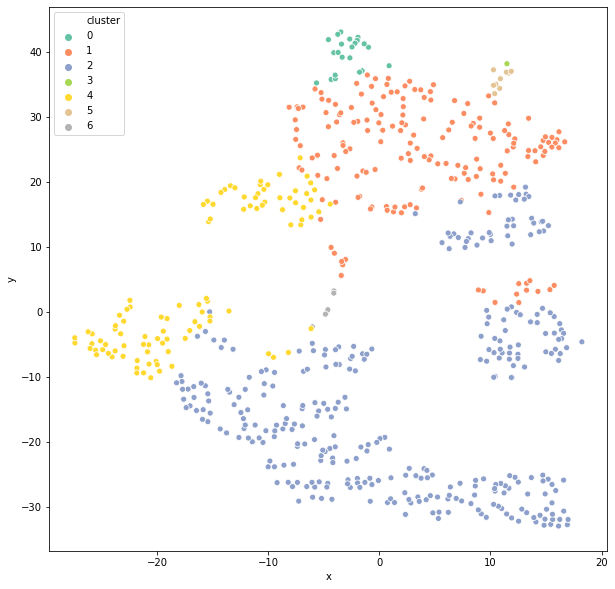

```python
plt.figure(figsize=(10,10))
sns.scatterplot(data=df,x='x',y='y',hue='cluster',legend='full',palette='Set2')
plt.show()
```

##### Explanation:

This is a visualization of the clusters created using tsne. As you can see from this graph, the clusters are not well defined. This is because the clusters do not look close together and far apart from one another. Although, there are some clusters within this visualization that appear to be well defined. For example, cluster 0, the dark green points, are close together.

Also, there is one anomaly in the dataset. This point falls in cluster 3. I can tell there is an anomaly because there is only one lime green dot on the graph. The k-mean algorithm is effected by outliers. If I remove this point from the dataset I should get a better k-mean output. I am going to try this below.

### d) Remove the outlier from the DataFrame new_with_clusters and assign the resulting DataFrame to the variable data_without_outlier

#### 1) Remove the outlier from the DataFrame

```python
data_without_outlier = new_with_clusters[new_with_clusters[0] == 3]
data_without_outlier.head()
```

|  | 0 | URL_LENGTH | NUMBER_SPECIAL_CHARACTERS | CONTENT_LENGTH | TCP_CONVERSATION_EXCHANGE | DIST_REMOTE_TCP_PORT | REMOTE_IPS | APP_BYTES | SOURCE_APP_PACKETS | REMOTE_APP_PACKETS | SOURCE_APP_BYTES | REMOTE_APP_BYTES | APP_PACKETS | DNS_QUERY_TIMES |
| --- | --- | --- | --- | --- | --- | --- | --- | --- | --- | --- | --- | --- | --- | --- |
| 357 | 3 | -0.106946 | -0.192055 | 0.289017 | 22.31154 | 1.296796 | 1.446809 | 21.681792 | 22.025956 | 21.698875 | 21.750727 | 21.354164 | 22.025956 | 0.740805 |

```python
data_without_outlier = new_with_clusters[new_with_clusters[0] != 3]
data_without_outlier.head()
```

|  | 0 | URL_LENGTH | NUMBER_SPECIAL_CHARACTERS | CONTENT_LENGTH | TCP_CONVERSATION_EXCHANGE | DIST_REMOTE_TCP_PORT | REMOTE_IPS | APP_BYTES | SOURCE_APP_PACKETS | REMOTE_APP_PACKETS | SOURCE_APP_BYTES | REMOTE_APP_BYTES | APP_PACKETS | DNS_QUERY_TIMES |
| --- | --- | --- | --- | --- | --- | --- | --- | --- | --- | --- | --- | --- | --- | --- |
| 0 | 0 | -1.550809 | -1.163403 | -0.447463 | 0.260262 | 2.778316 | 0.004083 | 0.461302 | 0.367052 | 0.294845 | -0.007965 | 0.541786 | 0.367052 | 2.280517 |
| 1 | 2 | -1.511786 | -1.163403 | -0.440290 | -0.099991 | -0.481028 | 0.004083 | -0.118317 | -0.100137 | -0.117101 | -0.116960 | -0.121674 | -0.100137 | -0.029051 |
| 2 | 2 | -1.472762 | -1.163403 | -0.441113 | -0.327519 | -0.481028 | -0.861553 | -0.381056 | -0.361763 | -0.340239 | -0.208195 | -0.410049 | -0.361763 | -0.798907 |
| 3 | 2 | -1.433739 | -1.163403 | -0.441113 | -0.327519 | -0.481028 | -0.861553 | -0.381056 | -0.361763 | -0.340239 | -0.208195 | -0.410049 | -0.361763 | -0.798907 |
| 4 | 2 | -1.394716 | -0.920566 | -0.426924 | -0.213755 | -0.481028 | -0.284462 | -0.247808 | -0.212263 | -0.185759 | -0.191353 | -0.248150 | -0.212263 | -0.029051 |

##### Explanation:

I removed the row that is an outlier from the DataFrame new_with_clusters. The outlier is in the cluster 3; therefore, I filtered out the row where the cluster, called column 0, is 3 by returning all rows that are not equal to 3. I assigned the resulting DataFrame to the variable called data_without_outlier

#### 2) Find the optimal value of k using the DataFrame called data_without_outlier

```python
d_without_outlier, largest_without_outlier = create_dic(data_without_outlier)
```

```python
"The new optimal value of K, after testing k as 3-49, is {}. The silhouette_score is {} when k is {}.".format(largest_without_outlier, d_without_outlier[largest_without_outlier],largest_without_outlier)
```

```
'The new optimal value of K, after testing k as 3-49, is 6. The silhouette_score is 0.4255432155734237 when k is 6.'
```

##### Explanation:

Find the optimal k value by passing in the DataFrame data_without_outlier to the create_dic function. I found that when there is no outlier in the DataFrame the optimal value of k is 6 . The silhouette score when the k value is 6 is 0.4255432155734237

#### 3) Call the Function do_kmeans with the DataFrame data_without_outlier and the optimal value of k, which is assigned to the variable largest_without_outlier

```python
kmeans, labels, centers = do_kmeans(data_without_outlier, largest_without_outlier)
```

#### 4) Visualize the results using TSNE

```python
tsne = TSNE(n_components=2, random_state=0) #n-components: what is the resuling dimension be (2 dimension)
X = data_without_outlier.values
X_2d = tsne.fit_transform(X)
```

```python
import pandas as pd
out = []
for i,(x,y) in enumerate(X_2d):
    out.append((labels[i],x,y))
df = pd.DataFrame(out,columns=['cluster','x','y'])
##print(out)
```

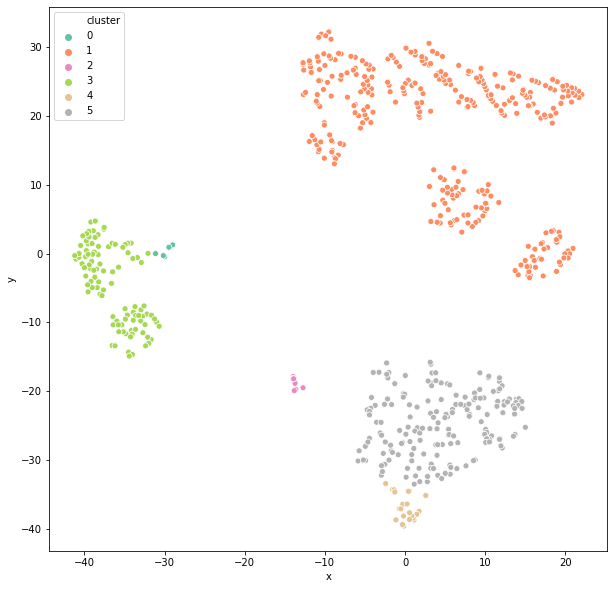

```python
plt.figure(figsize=(10,10))
sns.scatterplot(data=df,x='x',y='y',hue='cluster',legend='full',palette='Set2')
plt.show()
```

##### Explanation:

The resulting visualization is much better than the visualization created above. The clusters appear to be closer together and farther apart from one another. This demonstrates how k-means clustering can be effected by outliers, and shows the importance of removing them when using the alogrithm.

# Part 2: Random forest classification

*NOTE*: Use the `malicious_and_benign_train.csv` and `malicious_and_benign_test.csv` for your training and testing datasets, respectively.

- when doing analysis can do a better job here
- go back to original dataset not see if solution get is better than one where you drop categorical variables if better go back and insert 0 vectors. Encode the non-split dataset into train and test rename model on split date

```python
from sklearn.metrics import accuracy_score
from sklearn.naive_bayes import GaussianNB
from sklearn.model_selection import train_test_split
from sklearn.model_selection import GridSearchCV
from sklearn.linear_model import LogisticRegression
from sklearn.metrics import accuracy_score
from sklearn.metrics import classification_report, confusion_matrix
from sklearn.tree import DecisionTreeClassifier
from sklearn.tree import export_graphviz
from sklearn.model_selection import train_test_split
from sklearn.metrics import accuracy_score
from IPython.display import Image
from sklearn.model_selection import cross_val_score
# import pydotplus
```

## load in train data, malicious_and_benign_train.csv, and test data, malicious_and_benign_test.csv, as pandas DataFrames using pd.read_csv. Assign the resulting DataFrames to the variables data_train and data_test

```python
data_train = pd.read_csv('data/malicious_and_benign_train.csv')
data_test = pd.read_csv('data/malicious_and_benign_test.csv')
```

### a) Create a random forest classifier (2 points).

#### 1) Drop null values, categorical columns, and datatime columns for the DataFrames data_train and data_test

```python
data_train_replace_none = data_train.replace("None", np.nan)
data_train_no_nulls = data_train_replace_none.dropna()
```

```python
data_test_replace_none = data_test.replace("None", np.nan)
data_test_no_nulls = data_test_replace_none.dropna()
```

##### Explanation:

I replaced the None values in the DataFrames data_train and data_test with null values. Afterwards, I dropped the null values in both data_train and data_test. I reassigned the DataFrames to the variables data_train_no_nulls and data_test_no_nulls.

```python
# drop the datetime columns like I did in part 1
data_test_no_nulls = data_test_no_nulls.drop(columns = ["WHOIS_UPDATED_DATE","WHOIS_REGDATE"])
data_train_no_nulls = data_train_no_nulls.drop(columns = ["WHOIS_UPDATED_DATE","WHOIS_REGDATE"])
```

##### Explanation:

I dropped the dateTime columns in the DataFrames data_train and data_test: "WHOIS_UPDATED_DATE","WHOIS_REGDATE". I reassigned the DataFrames to the variables data_train_no_nulls and data_test_no_nulls.

```python
#drop the categorical columns
data_test_only_numerical = data_test_no_nulls[list(data_test_no_nulls.describe().columns)]

data_train_only_numerical = data_train_no_nulls[list(data_train_no_nulls.describe().columns)]
```

##### Explanation:

I filtered out the categorical columns in the DataFrames data_test_no_nulls and data_train_no_nulls by using the columns returned from .describe ( these will be only the numerical columns in the DataFrames). Then, I re-assigned the DataFrames to the variables data_test_only_numerical and data_train_only_numerical.

#### 2) Assign the X column values and Y column values in data_train_only_numerical and data_test_only_numerical to variables.

- The Y column values are the values you are trying predict

```python
X_train= data_train_only_numerical.ix[:,:-1] #slice dataframe all rows and all columns but the last
X_test = data_test_only_numerical.ix[:,:-1]
```

##### Explanation:

The last column, Type, in both data_train_only_numerical and data_test_only_numerical is the Y value. The Type column indicates whether a website is malicious or benign, and this is what we are trying to predict. Therefore, all numerical columns, excluding the column Type, should be the X values. In the code above I am slicing both DataFrames to return all columns but the last column, which is the Type column, and assigning the results to X_train and X_test.

```python
y_train= data_train_only_numerical.ix[:,-1] #only the last column
y_test = data_test_only_numerical.ix[:,-1]
```

##### Explanation:

The last column, Type, in both data_train_only_numerical and data_test_only_numerical is the Y value. The Type column indicates whether a website is malicious or benign, and this is what we are trying to predict. Therefore, the column Type is the Y value. In the code above I am slicing both DataFrames to return only the last column, which is the Type column, and I am assigning the results to y_train and y_test.

#### 3) Create a Random Forest classifier

```python
#seed = 7

model = RandomForestClassifier(
    oob_score=True,
    n_estimators=10,
    #random_state=seed,
    criterion='entropy')
    #max_depth=None,
    #min_samples_split=2)

model
```

```
RandomForestClassifier(bootstrap=True, class_weight=None, criterion='entropy',
                       max_depth=None, max_features='auto', max_leaf_nodes=None,
                       min_impurity_decrease=0.0, min_impurity_split=None,
                       min_samples_leaf=1, min_samples_split=2,
                       min_weight_fraction_leaf=0.0, n_estimators=10,
                       n_jobs=None, oob_score=True, random_state=None,
                       verbose=0, warm_start=False)
```

#### 4) Train the RandomForestClassifier with the training data

```python
model.fit(X_train,y_train)
```

```
RandomForestClassifier(bootstrap=True, class_weight=None, criterion='entropy',
                       max_depth=None, max_features='auto', max_leaf_nodes=None,
                       min_impurity_decrease=0.0, min_impurity_split=None,
                       min_samples_leaf=1, min_samples_split=2,
                       min_weight_fraction_leaf=0.0, n_estimators=10,
                       n_jobs=None, oob_score=True, random_state=None,
                       verbose=0, warm_start=False)
```

##### Explanation:

Before calculating the accuracy score of my random forest classifier, which is assigned to the variable model, I need to fit the model. In order to use this I used the .fit method on the RandomForestClassifier object and passed in the X_train values and y_train values. The .fit melthod builds a forest of trees using the training data.

### b) Report the accuracy of your resulting classifier. (2 points).

- can call .score on fitted model or accuracy score from sklearn

Tasks:

- Report the accuracy of your resulting classifier (2 points).
- predict values using the classifier (1pt)
- calculate the accuracy of your classifier by making predictions on the TEST dataset (1pt)

Hint: scikit-learn has a function called accuracy_score() for this

#### 1) Predict values using the classifier, which i assigned to the variable model. Use the test data, X_test, to make predictions. (1 points)

```python
#model.fit(X_train,y_train)
data_test_only_numerical_copy = data_test_only_numerical.copy()

y_pred = model.predict(X_test)
data_test_only_numerical_copy['predicted_rf_tree_old'] = y_pred
```

```python
print("Predicted values of Classifer: ")
y_pred
```

```
Predicted values of Classifer:
```

```
array([0, 0, 0, 0, 0, 0, 0, 0, 0, 0, 0, 0, 0, 0, 0, 0, 0, 0, 0, 0, 1, 0,
       0, 0, 0, 0, 0, 0, 0, 0, 0, 0, 0, 0, 0, 0, 0, 0, 0, 0, 0, 0, 1, 0,
       0, 1, 0, 0, 0, 0, 1, 0, 0, 0, 0, 0, 1, 0, 0, 0, 0, 0, 0, 0, 0, 0,
       0, 0, 0, 0, 0, 0, 0, 0, 0, 0, 0, 0, 0, 0, 1, 0, 0, 0, 0, 0, 0, 0,
       0, 0, 0, 0, 0, 0, 0, 0, 0, 0, 0, 0, 0, 0, 0, 0, 0, 0, 0, 0, 0, 1,
       0, 0, 0, 0, 1, 1, 0, 0, 0, 0, 0, 0, 0, 0, 0, 0, 0, 0, 0])
```

##### Explanation:

y_predict, shown above, is the assigned to the predicted values of my resulting classifier. The predicted values of my classifer are printed above.

I also made a copy of the DataFrame data_test_only_numerical and assigned the copy to the variable data_test_only_numerical_copy. I added a column to data_test_only_numerical_copy called predicted_rf_tree_old. The column predicted_rf_tree_old has predicted values of Type. Below I printed out the Columns predicted_rf_tree_old' and 'Type' next to eachother to compare actual values, Type, with the predicted value, predicted_rf_tree_old. From reviewing the results you can see that for the most part the data is accurate; although, there are some predicted values of type that are wrong. For example, index 47 has a predicted_rf_tree_old value of 1, but the actual Type of the website is 0.

```python
data_test_only_numerical_copy[['predicted_rf_tree_old', 'Type']]
```

|  | predicted_rf_tree_old | Type |
| --- | --- | --- |
| 0 | 0 | 0 |
| 2 | 0 | 0 |
| 3 | 0 | 0 |
| 5 | 0 | 0 |
| 14 | 0 | 0 |
| 15 | 0 | 0 |
| 17 | 0 | 0 |
| 21 | 0 | 0 |
| 22 | 0 | 0 |
| 24 | 0 | 0 |
| 29 | 0 | 0 |
| 31 | 0 | 0 |
| 32 | 0 | 0 |
| 36 | 0 | 0 |
| 39 | 0 | 0 |
| 41 | 0 | 0 |
| 42 | 0 | 0 |
| 43 | 0 | 0 |
| 45 | 0 | 0 |
| 46 | 0 | 0 |
| 47 | 1 | 0 |
| 52 | 0 | 0 |
| 56 | 0 | 0 |
| 57 | 0 | 0 |
| 59 | 0 | 0 |
| 68 | 0 | 1 |
| 69 | 0 | 0 |
| 71 | 0 | 0 |
| 72 | 0 | 0 |
| 79 | 0 | 0 |
| ... | ... | ... |
| 271 | 0 | 0 |
| 274 | 0 | 0 |
| 275 | 0 | 0 |
| 278 | 0 | 0 |
| 279 | 0 | 0 |
| 289 | 0 | 0 |
| 293 | 0 | 0 |
| 294 | 0 | 0 |
| 298 | 0 | 0 |
| 303 | 0 | 0 |
| 308 | 1 | 0 |
| 310 | 0 | 0 |
| 314 | 0 | 0 |
| 316 | 0 | 0 |
| 319 | 0 | 0 |
| 323 | 1 | 1 |
| 329 | 1 | 1 |
| 333 | 0 | 0 |
| 334 | 0 | 0 |
| 336 | 0 | 0 |
| 339 | 0 | 0 |
| 340 | 0 | 0 |
| 342 | 0 | 0 |
| 343 | 0 | 0 |
| 348 | 0 | 0 |
| 350 | 0 | 0 |
| 351 | 0 | 0 |
| 353 | 0 | 0 |
| 354 | 0 | 0 |
| 355 | 0 | 0 |

129 rows × 2 columns

#### 2) Calculate the accuracy of your classifier by making predictions on the TEST dataset. In the code below I used the method .score to return the mean accuracy of the model using the test data (1pt)

- calculate the accuracy of your classifier by making predictions on the TEST dataset (1pt)

```python
accuracy = model.score(X_test, y_test)
print("Accuracy: %.2f%%" % (accuracy * 100.0))
```

```
Accuracy: 96.12%
```

##### Explanation:

I am evaluating my predictions by using the method .score on the RandomForestClassifier object called model. I passed in X_test values and y_test values, and found that the resulting classifier has a mean accuracy score of 96.12%.

Note: you can also use the accuracy_score function to get the accuracy score. Below I demonstrated how to use the accuracy_score function. I passed in data_test_only_numerical["Type"] and y_predict (the predicted lables) to get the accuracy score. The resulting accuracy score is the same, 96.12%.

```python
accuracy = accuracy_score(data_test_only_numerical["Type"], y_pred)
print("Accuracy: {0:.2%}".format(accuracy))
```

```
Accuracy: 96.12%
```

##### Explanation:

```python
from sklearn.metrics import classification_report, confusion_matrix
print(confusion_matrix(y_test, y_pred))
print(classification_report(y_test, y_pred))
```

```
[[118   3]
 [  2   6]]
              precision    recall  f1-score   support

           0       0.98      0.98      0.98       121
           1       0.67      0.75      0.71         8

    accuracy                           0.96       129
   macro avg       0.82      0.86      0.84       129
weighted avg       0.96      0.96      0.96       129
```

### c) Report the most important feature (2 points).

- feature importance, example to do this with feature classification

Tasks:

- Please include a figure that supports this result (1pt)
- Provide an explanation of why this feature seems most important (1pt)

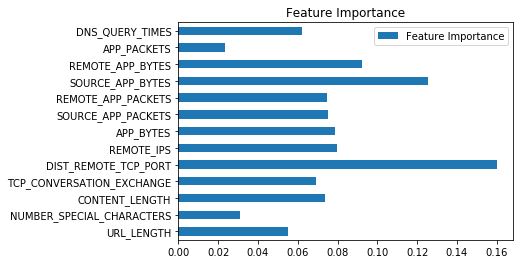

```python
feat_importance = model.feature_importances_

pd.DataFrame({'Feature Importance':feat_importance},
            index=list(X_test)).plot(kind='barh')
plt.title("Feature Importance")
```

##### Explanation:

The graph above shows how important each feature is on the classifier. The higher the number the more important the feature. As you can see, from the graph shown above, the feature that has the most importance/is the most influential is DIST_REMOTE_TCP_PORT when deciding if a website is beign or malicious. This feature has the highest number among all the features of 0.16!

### d) Try tuning the hyperparameters to see if you can improve the accuracy (3 points).

- number of estimators and depth of tree
- look at hyperparamaeters

TASKS:

- Comparison with original model, show improvement (2pts)
- Provide a possible explanation for improvement in score (1pt)

BONUS: The top 5 accuracy scores in the class will receive a 2-point bonus.

```python
scores = cross_val_score(model, X_train, y_train, cv =5) #X, y, cv=5)
scores
```

```
array([0.92156863, 0.95098039, 0.95098039, 0.96039604, 0.94      ])
```

##### Explanation:

I am using the cross-validation so I will be able to run cross-validation on the classifier later in my code.

#### 1) set the parameters in param_grid. These parameters will be used when using the GridSearchCV function to find the best model

```python
param_grid = {
#                 'n_estimators': [5, 10, 15, 20, 25],
#                  'max_depth': [2, 5, 7, 9]
                'n_estimators': list(range(5,41,5)),
                'max_depth': list(range(2, 11, 2)),
                #'min_samples_split': [0.1],
                'random_state': list(range(0,12))


#                  'n_estimators': list(range(5, 101, 5)),#[5, 10, 15, 20, 25, 30, 100],
                 #'n_estimators':[5, 10, 15, 20, 25],
                 #'max_depth': list(range(2, 33, 2))
                 #'max_depth': [2, 5, 7, 9],
             }
```

##### Explanation:

These are going to be my hyperparameters. For n_estimators, I created a list of numbers that start at 5 and end at 40. Each number in the list will increment by 5. I created a list of max_depth to start at 2 and end at 10. Each number in the list will increment by 2. As well, i have a random_state parameter that is a list of numbers between 0 and 11. Each number in the list is incremented by 1. The list of numbers in the hyperparameters will be used/tested on the model when I use the GridSearchCV function.

#### 2) Use GridSearchCV to find the best model

```python
from sklearn.model_selection import GridSearchCV

grid_clf = GridSearchCV(model, param_grid, cv=10)
grid_clf.fit(X_train,y_train)
```

[output not shown]

[output cut: 5785 more lines]

[output not shown]

```
GridSearchCV(cv=10, error_score='raise-deprecating',
             estimator=RandomForestClassifier(bootstrap=True, class_weight=None,
                                              criterion='entropy',
                                              max_depth=None,
                                              max_features='auto',
                                              max_leaf_nodes=None,
                                              min_impurity_decrease=0.0,
                                              min_impurity_split=None,
                                              min_samples_leaf=1,
                                              min_samples_split=2,
                                              min_weight_fraction_leaf=0.0,
                                              n_estimators=10, n_jobs=None,
                                              oob_score=True, random_state=None,
                                              verbose=0, warm_start=False),
             iid='warn', n_jobs=None,
             param_grid={'max_depth': [2, 4, 6, 8, 10],
                         'n_estimators': [5, 10, 15, 20, 25, 30, 35, 40],
                         'random_state': [0, 1, 2, 3, 4, 5, 6, 7, 8, 9, 10,
                                          11]},
             pre_dispatch='2*n_jobs', refit=True, return_train_score=False,
             scoring=None, verbose=0)
```

```python
grid_clf.best_params_
```

```
{'max_depth': 8, 'n_estimators': 25, 'random_state': 3}
```

##### Explanation:

After using GridSearchCV function on the model and parameters above I found that the best parameters for the model. The best parameters include max_depth of 8, n_estimators of 25, and a random_state of 3.

```python
results = pd.DataFrame(grid_clf.cv_results_)
results
```

|  | mean_fit_time | std_fit_time | mean_score_time | std_score_time | param_max_depth | param_n_estimators | param_random_state | params | split0_test_score | split1_test_score | ... | split3_test_score | split4_test_score | split5_test_score | split6_test_score | split7_test_score | split8_test_score | split9_test_score | mean_test_score | std_test_score | rank_test_score |
| --- | --- | --- | --- | --- | --- | --- | --- | --- | --- | --- | --- | --- | --- | --- | --- | --- | --- | --- | --- | --- | --- |
| 0 | 0.019895 | 0.016873 | 0.014110 | 0.023000 | 2 | 5 | 0 | {'max_depth': 2, 'n_estimators': 5, 'random_st... | 0.921569 | 0.921569 | ... | 0.921569 | 0.921569 | 0.921569 | 0.921569 | 0.921569 | 0.94 | 0.938776 | 0.925049 | 0.007071 | 380 |
| 1 | 0.029322 | 0.024727 | 0.002706 | 0.000480 | 2 | 5 | 1 | {'max_depth': 2, 'n_estimators': 5, 'random_st... | 0.921569 | 0.921569 | ... | 0.921569 | 0.921569 | 0.921569 | 0.921569 | 0.921569 | 0.94 | 0.938776 | 0.925049 | 0.007071 | 380 |
| 2 | 0.035676 | 0.028382 | 0.002526 | 0.000240 | 2 | 5 | 2 | {'max_depth': 2, 'n_estimators': 5, 'random_st... | 0.921569 | 0.921569 | ... | 0.921569 | 0.921569 | 0.921569 | 0.921569 | 0.921569 | 0.94 | 0.938776 | 0.925049 | 0.007071 | 380 |
| 3 | 0.037078 | 0.027984 | 0.002797 | 0.000447 | 2 | 5 | 3 | {'max_depth': 2, 'n_estimators': 5, 'random_st... | 0.921569 | 0.921569 | ... | 0.921569 | 0.921569 | 0.921569 | 0.921569 | 0.921569 | 0.94 | 0.938776 | 0.925049 | 0.007071 | 380 |
| 4 | 0.037320 | 0.028293 | 0.003073 | 0.000432 | 2 | 5 | 4 | {'max_depth': 2, 'n_estimators': 5, 'random_st... | 0.921569 | 0.921569 | ... | 0.921569 | 0.921569 | 0.921569 | 0.921569 | 0.921569 | 0.94 | 0.938776 | 0.925049 | 0.007071 | 380 |
| 5 | 0.035923 | 0.027403 | 0.002755 | 0.000467 | 2 | 5 | 5 | {'max_depth': 2, 'n_estimators': 5, 'random_st... | 0.921569 | 0.921569 | ... | 0.921569 | 0.921569 | 0.921569 | 0.921569 | 0.921569 | 0.94 | 0.938776 | 0.925049 | 0.007071 | 380 |
| 6 | 0.032677 | 0.027815 | 0.013311 | 0.021298 | 2 | 5 | 6 | {'max_depth': 2, 'n_estimators': 5, 'random_st... | 0.921569 | 0.921569 | ... | 0.921569 | 0.921569 | 0.921569 | 0.921569 | 0.921569 | 0.94 | 0.938776 | 0.925049 | 0.007071 | 380 |
| 7 | 0.025275 | 0.023737 | 0.008627 | 0.017820 | 2 | 5 | 7 | {'max_depth': 2, 'n_estimators': 5, 'random_st... | 0.921569 | 0.921569 | ... | 0.921569 | 0.921569 | 0.921569 | 0.921569 | 0.921569 | 0.94 | 0.938776 | 0.925049 | 0.007071 | 380 |
| 8 | 0.035503 | 0.027405 | 0.002699 | 0.000348 | 2 | 5 | 8 | {'max_depth': 2, 'n_estimators': 5, 'random_st... | 0.921569 | 0.921569 | ... | 0.921569 | 0.921569 | 0.921569 | 0.921569 | 0.921569 | 0.94 | 0.938776 | 0.925049 | 0.007071 | 380 |
| 9 | 0.036014 | 0.028597 | 0.002582 | 0.000274 | 2 | 5 | 9 | {'max_depth': 2, 'n_estimators': 5, 'random_st... | 0.921569 | 0.921569 | ... | 0.921569 | 0.921569 | 0.921569 | 0.921569 | 0.921569 | 0.94 | 0.938776 | 0.925049 | 0.007071 | 380 |
| 10 | 0.025838 | 0.026177 | 0.007839 | 0.015438 | 2 | 5 | 10 | {'max_depth': 2, 'n_estimators': 5, 'random_st... | 0.921569 | 0.921569 | ... | 0.921569 | 0.921569 | 0.921569 | 0.921569 | 0.921569 | 0.94 | 0.938776 | 0.925049 | 0.007071 | 380 |
| 11 | 0.038100 | 0.028615 | 0.002906 | 0.000448 | 2 | 5 | 11 | {'max_depth': 2, 'n_estimators': 5, 'random_st... | 0.921569 | 0.921569 | ... | 0.921569 | 0.921569 | 0.921569 | 0.921569 | 0.921569 | 0.94 | 0.938776 | 0.925049 | 0.007071 | 380 |
| 12 | 0.054020 | 0.027419 | 0.003136 | 0.000308 | 2 | 10 | 0 | {'max_depth': 2, 'n_estimators': 10, 'random_s... | 0.921569 | 0.921569 | ... | 0.921569 | 0.921569 | 0.921569 | 0.921569 | 0.921569 | 0.94 | 0.938776 | 0.925049 | 0.007071 | 380 |
| 13 | 0.050699 | 0.029310 | 0.009501 | 0.018112 | 2 | 10 | 1 | {'max_depth': 2, 'n_estimators': 10, 'random_s... | 0.921569 | 0.921569 | ... | 0.921569 | 0.921569 | 0.921569 | 0.921569 | 0.921569 | 0.94 | 0.938776 | 0.925049 | 0.007071 | 380 |
| 14 | 0.049962 | 0.027674 | 0.008397 | 0.015419 | 2 | 10 | 2 | {'max_depth': 2, 'n_estimators': 10, 'random_s... | 0.921569 | 0.921569 | ... | 0.921569 | 0.921569 | 0.921569 | 0.921569 | 0.921569 | 0.94 | 0.938776 | 0.925049 | 0.007071 | 380 |
| 15 | 0.045122 | 0.027818 | 0.009056 | 0.017639 | 2 | 10 | 3 | {'max_depth': 2, 'n_estimators': 10, 'random_s... | 0.921569 | 0.921569 | ... | 0.921569 | 0.921569 | 0.921569 | 0.921569 | 0.921569 | 0.94 | 0.938776 | 0.925049 | 0.007071 | 380 |
| 16 | 0.048774 | 0.028387 | 0.002979 | 0.000275 | 2 | 10 | 4 | {'max_depth': 2, 'n_estimators': 10, 'random_s... | 0.921569 | 0.921569 | ... | 0.921569 | 0.921569 | 0.921569 | 0.921569 | 0.921569 | 0.94 | 0.938776 | 0.925049 | 0.007071 | 380 |
| 17 | 0.050183 | 0.028397 | 0.009046 | 0.017702 | 2 | 10 | 5 | {'max_depth': 2, 'n_estimators': 10, 'random_s... | 0.921569 | 0.921569 | ... | 0.921569 | 0.921569 | 0.921569 | 0.921569 | 0.921569 | 0.94 | 0.938776 | 0.925049 | 0.007071 | 380 |
| 18 | 0.046405 | 0.029579 | 0.003297 | 0.000478 | 2 | 10 | 6 | {'max_depth': 2, 'n_estimators': 10, 'random_s... | 0.921569 | 0.921569 | ... | 0.921569 | 0.921569 | 0.921569 | 0.921569 | 0.921569 | 0.94 | 0.938776 | 0.925049 | 0.007071 | 380 |
| 19 | 0.062274 | 0.026222 | 0.003172 | 0.000210 | 2 | 10 | 7 | {'max_depth': 2, 'n_estimators': 10, 'random_s... | 0.921569 | 0.921569 | ... | 0.921569 | 0.921569 | 0.921569 | 0.921569 | 0.921569 | 0.94 | 0.938776 | 0.925049 | 0.007071 | 380 |
| 20 | 0.045085 | 0.027438 | 0.008503 | 0.015908 | 2 | 10 | 8 | {'max_depth': 2, 'n_estimators': 10, 'random_s... | 0.921569 | 0.921569 | ... | 0.921569 | 0.921569 | 0.921569 | 0.921569 | 0.921569 | 0.94 | 0.938776 | 0.925049 | 0.007071 | 380 |
| 21 | 0.057319 | 0.028953 | 0.003121 | 0.000290 | 2 | 10 | 9 | {'max_depth': 2, 'n_estimators': 10, 'random_s... | 0.921569 | 0.921569 | ... | 0.921569 | 0.921569 | 0.921569 | 0.921569 | 0.921569 | 0.94 | 0.938776 | 0.925049 | 0.007071 | 380 |
| 22 | 0.049942 | 0.027968 | 0.008376 | 0.015544 | 2 | 10 | 10 | {'max_depth': 2, 'n_estimators': 10, 'random_s... | 0.921569 | 0.921569 | ... | 0.921569 | 0.921569 | 0.921569 | 0.921569 | 0.921569 | 0.94 | 0.938776 | 0.925049 | 0.007071 | 380 |
| 23 | 0.056856 | 0.027924 | 0.003339 | 0.000178 | 2 | 10 | 11 | {'max_depth': 2, 'n_estimators': 10, 'random_s... | 0.921569 | 0.921569 | ... | 0.921569 | 0.921569 | 0.921569 | 0.921569 | 0.921569 | 0.94 | 0.938776 | 0.925049 | 0.007071 | 380 |
| 24 | 0.056121 | 0.026376 | 0.013050 | 0.020146 | 2 | 15 | 0 | {'max_depth': 2, 'n_estimators': 15, 'random_s... | 0.921569 | 0.921569 | ... | 0.921569 | 0.921569 | 0.921569 | 0.921569 | 0.921569 | 0.94 | 0.938776 | 0.925049 | 0.007071 | 380 |
| 25 | 0.068477 | 0.025611 | 0.003353 | 0.000439 | 2 | 15 | 1 | {'max_depth': 2, 'n_estimators': 15, 'random_s... | 0.921569 | 0.921569 | ... | 0.921569 | 0.921569 | 0.921569 | 0.921569 | 0.921569 | 0.94 | 0.938776 | 0.925049 | 0.007071 | 380 |
| 26 | 0.067375 | 0.024637 | 0.002894 | 0.000153 | 2 | 15 | 2 | {'max_depth': 2, 'n_estimators': 15, 'random_s... | 0.921569 | 0.921569 | ... | 0.921569 | 0.921569 | 0.921569 | 0.921569 | 0.921569 | 0.94 | 0.938776 | 0.925049 | 0.007071 | 380 |
| 27 | 0.064819 | 0.023736 | 0.002865 | 0.000106 | 2 | 15 | 3 | {'max_depth': 2, 'n_estimators': 15, 'random_s... | 0.921569 | 0.921569 | ... | 0.921569 | 0.921569 | 0.921569 | 0.921569 | 0.921569 | 0.94 | 0.938776 | 0.925049 | 0.007071 | 380 |
| 28 | 0.062305 | 0.026614 | 0.008672 | 0.015311 | 2 | 15 | 4 | {'max_depth': 2, 'n_estimators': 15, 'random_s... | 0.921569 | 0.921569 | ... | 0.921569 | 0.921569 | 0.921569 | 0.921569 | 0.921569 | 0.94 | 0.938776 | 0.925049 | 0.007071 | 380 |
| 29 | 0.065788 | 0.026246 | 0.019806 | 0.024908 | 2 | 15 | 5 | {'max_depth': 2, 'n_estimators': 15, 'random_s... | 0.921569 | 0.921569 | ... | 0.921569 | 0.921569 | 0.921569 | 0.921569 | 0.921569 | 0.94 | 0.938776 | 0.925049 | 0.007071 | 380 |
| ... | ... | ... | ... | ... | ... | ... | ... | ... | ... | ... | ... | ... | ... | ... | ... | ... | ... | ... | ... | ... | ... |
| 450 | 0.122998 | 0.019835 | 0.008980 | 0.015203 | 10 | 30 | 6 | {'max_depth': 10, 'n_estimators': 30, 'random_... | 0.941176 | 0.901961 | ... | 0.960784 | 0.941176 | 0.980392 | 0.960784 | 0.960784 | 0.96 | 0.938776 | 0.948718 | 0.020101 | 57 |
| 451 | 0.121462 | 0.021614 | 0.008812 | 0.015178 | 10 | 30 | 7 | {'max_depth': 10, 'n_estimators': 30, 'random_... | 0.941176 | 0.941176 | ... | 0.980392 | 0.941176 | 0.941176 | 0.960784 | 0.960784 | 0.96 | 0.938776 | 0.952663 | 0.013202 | 19 |
| 452 | 0.134575 | 0.026309 | 0.003821 | 0.000171 | 10 | 30 | 8 | {'max_depth': 10, 'n_estimators': 30, 'random_... | 0.901961 | 0.941176 | ... | 0.980392 | 0.960784 | 0.980392 | 0.960784 | 0.960784 | 0.96 | 0.959184 | 0.956607 | 0.021141 | 5 |
| 453 | 0.120437 | 0.020485 | 0.008792 | 0.015269 | 10 | 30 | 9 | {'max_depth': 10, 'n_estimators': 30, 'random_... | 0.921569 | 0.921569 | ... | 0.980392 | 0.921569 | 0.980392 | 0.960784 | 0.960784 | 0.96 | 0.938776 | 0.950690 | 0.022055 | 34 |
| 454 | 0.125512 | 0.024399 | 0.003736 | 0.000148 | 10 | 30 | 10 | {'max_depth': 10, 'n_estimators': 30, 'random_... | 0.941176 | 0.921569 | ... | 0.960784 | 0.941176 | 0.941176 | 0.941176 | 0.960784 | 0.96 | 0.938776 | 0.944773 | 0.011772 | 149 |
| 455 | 0.116125 | 0.015113 | 0.013981 | 0.020464 | 10 | 30 | 11 | {'max_depth': 10, 'n_estimators': 30, 'random_... | 0.941176 | 0.921569 | ... | 0.960784 | 0.941176 | 0.960784 | 0.960784 | 0.941176 | 0.96 | 0.938776 | 0.946746 | 0.012617 | 102 |
| 456 | 0.135884 | 0.022471 | 0.014155 | 0.020239 | 10 | 35 | 0 | {'max_depth': 10, 'n_estimators': 35, 'random_... | 0.941176 | 0.921569 | ... | 0.960784 | 0.941176 | 0.960784 | 0.960784 | 0.960784 | 0.96 | 0.938776 | 0.946746 | 0.015380 | 102 |
| 457 | 0.147070 | 0.026748 | 0.004015 | 0.000165 | 10 | 35 | 1 | {'max_depth': 10, 'n_estimators': 35, 'random_... | 0.921569 | 0.921569 | ... | 0.960784 | 0.921569 | 0.941176 | 0.960784 | 0.960784 | 0.94 | 0.938776 | 0.942801 | 0.016394 | 189 |
| 458 | 0.130227 | 0.020261 | 0.019464 | 0.023732 | 10 | 35 | 2 | {'max_depth': 10, 'n_estimators': 35, 'random_... | 0.941176 | 0.901961 | ... | 0.980392 | 0.941176 | 0.960784 | 0.960784 | 0.980392 | 0.96 | 0.938776 | 0.950690 | 0.022055 | 34 |
| 459 | 0.146167 | 0.025889 | 0.004172 | 0.000378 | 10 | 35 | 3 | {'max_depth': 10, 'n_estimators': 35, 'random_... | 0.941176 | 0.921569 | ... | 0.960784 | 0.941176 | 0.980392 | 0.960784 | 0.980392 | 0.96 | 0.938776 | 0.952663 | 0.018138 | 19 |
| 460 | 0.145786 | 0.025245 | 0.004059 | 0.000196 | 10 | 35 | 4 | {'max_depth': 10, 'n_estimators': 35, 'random_... | 0.941176 | 0.921569 | ... | 0.941176 | 0.960784 | 0.960784 | 0.960784 | 0.980392 | 0.94 | 0.938776 | 0.946746 | 0.017825 | 102 |
| 461 | 0.152043 | 0.026130 | 0.004220 | 0.000492 | 10 | 35 | 5 | {'max_depth': 10, 'n_estimators': 35, 'random_... | 0.921569 | 0.901961 | ... | 0.960784 | 0.941176 | 0.960784 | 0.960784 | 0.960784 | 0.96 | 0.938776 | 0.944773 | 0.019252 | 149 |
| 462 | 0.141410 | 0.025060 | 0.004095 | 0.000276 | 10 | 35 | 6 | {'max_depth': 10, 'n_estimators': 35, 'random_... | 0.941176 | 0.901961 | ... | 0.941176 | 0.941176 | 0.980392 | 0.960784 | 0.960784 | 0.96 | 0.938776 | 0.944773 | 0.021166 | 149 |
| 463 | 0.141460 | 0.025188 | 0.009216 | 0.015513 | 10 | 35 | 7 | {'max_depth': 10, 'n_estimators': 35, 'random_... | 0.941176 | 0.941176 | ... | 0.980392 | 0.941176 | 0.941176 | 0.960784 | 0.960784 | 0.96 | 0.938776 | 0.954635 | 0.015528 | 10 |
| 464 | 0.145139 | 0.024793 | 0.004044 | 0.000145 | 10 | 35 | 8 | {'max_depth': 10, 'n_estimators': 35, 'random_... | 0.921569 | 0.901961 | ... | 1.000000 | 0.960784 | 0.980392 | 0.960784 | 0.960784 | 0.96 | 0.938776 | 0.952663 | 0.026753 | 19 |
| 465 | 0.144945 | 0.026046 | 0.004087 | 0.000301 | 10 | 35 | 9 | {'max_depth': 10, 'n_estimators': 35, 'random_... | 0.941176 | 0.921569 | ... | 0.980392 | 0.921569 | 0.980392 | 0.960784 | 0.960784 | 0.96 | 0.938776 | 0.952663 | 0.020158 | 19 |
| 466 | 0.139162 | 0.025246 | 0.009089 | 0.015258 | 10 | 35 | 10 | {'max_depth': 10, 'n_estimators': 35, 'random_... | 0.960784 | 0.921569 | ... | 0.980392 | 0.941176 | 0.960784 | 0.941176 | 0.980392 | 0.96 | 0.918367 | 0.950690 | 0.020497 | 34 |
| 467 | 0.141694 | 0.025973 | 0.009200 | 0.015229 | 10 | 35 | 11 | {'max_depth': 10, 'n_estimators': 35, 'random_... | 0.941176 | 0.921569 | ... | 0.980392 | 0.941176 | 0.960784 | 0.960784 | 0.941176 | 0.96 | 0.938776 | 0.948718 | 0.015791 | 57 |
| 468 | 0.171974 | 0.021212 | 0.004288 | 0.000108 | 10 | 40 | 0 | {'max_depth': 10, 'n_estimators': 40, 'random_... | 0.941176 | 0.921569 | ... | 0.960784 | 0.921569 | 0.960784 | 0.960784 | 0.960784 | 0.96 | 0.938776 | 0.944773 | 0.017126 | 149 |
| 469 | 0.156586 | 0.027293 | 0.004384 | 0.000308 | 10 | 40 | 1 | {'max_depth': 10, 'n_estimators': 40, 'random_... | 0.921569 | 0.921569 | ... | 0.960784 | 0.921569 | 0.960784 | 0.960784 | 0.960784 | 0.94 | 0.938776 | 0.944773 | 0.017238 | 149 |
| 470 | 0.160269 | 0.024631 | 0.009462 | 0.015248 | 10 | 40 | 2 | {'max_depth': 10, 'n_estimators': 40, 'random_... | 0.941176 | 0.901961 | ... | 0.980392 | 0.941176 | 0.960784 | 0.960784 | 0.980392 | 0.96 | 0.938776 | 0.952663 | 0.021993 | 19 |
| 471 | 0.167057 | 0.024906 | 0.009406 | 0.015160 | 10 | 40 | 3 | {'max_depth': 10, 'n_estimators': 40, 'random_... | 0.941176 | 0.921569 | ... | 0.960784 | 0.941176 | 0.980392 | 0.960784 | 0.960784 | 0.96 | 0.938776 | 0.950690 | 0.015949 | 34 |
| 472 | 0.159979 | 0.024649 | 0.009495 | 0.015539 | 10 | 40 | 4 | {'max_depth': 10, 'n_estimators': 40, 'random_... | 0.941176 | 0.921569 | ... | 0.941176 | 0.960784 | 0.980392 | 0.960784 | 0.980392 | 0.94 | 0.938776 | 0.950690 | 0.018319 | 34 |
| 473 | 0.156239 | 0.026338 | 0.014553 | 0.020546 | 10 | 40 | 5 | {'max_depth': 10, 'n_estimators': 40, 'random_... | 0.921569 | 0.901961 | ... | 0.960784 | 0.941176 | 0.960784 | 0.960784 | 0.960784 | 0.96 | 0.938776 | 0.944773 | 0.019252 | 149 |
| 474 | 0.160873 | 0.026495 | 0.009541 | 0.015941 | 10 | 40 | 6 | {'max_depth': 10, 'n_estimators': 40, 'random_... | 0.921569 | 0.901961 | ... | 0.941176 | 0.941176 | 0.980392 | 0.960784 | 0.960784 | 0.96 | 0.938776 | 0.942801 | 0.022292 | 189 |
| 475 | 0.172873 | 0.021387 | 0.004261 | 0.000148 | 10 | 40 | 7 | {'max_depth': 10, 'n_estimators': 40, 'random_... | 0.941176 | 0.941176 | ... | 0.980392 | 0.941176 | 0.941176 | 0.960784 | 0.960784 | 0.96 | 0.938776 | 0.954635 | 0.015528 | 10 |
| 476 | 0.150151 | 0.026457 | 0.019547 | 0.023246 | 10 | 40 | 8 | {'max_depth': 10, 'n_estimators': 40, 'random_... | 0.941176 | 0.901961 | ... | 1.000000 | 0.960784 | 0.980392 | 0.960784 | 0.960784 | 0.96 | 0.938776 | 0.956607 | 0.024689 | 5 |
| 477 | 0.164504 | 0.022916 | 0.004295 | 0.000108 | 10 | 40 | 9 | {'max_depth': 10, 'n_estimators': 40, 'random_... | 0.921569 | 0.901961 | ... | 0.980392 | 0.921569 | 0.980392 | 0.960784 | 0.960784 | 0.96 | 0.938776 | 0.948718 | 0.025221 | 57 |
| 478 | 0.165391 | 0.024650 | 0.004244 | 0.000085 | 10 | 40 | 10 | {'max_depth': 10, 'n_estimators': 40, 'random_... | 0.960784 | 0.921569 | ... | 0.980392 | 0.941176 | 0.941176 | 0.941176 | 0.960784 | 0.96 | 0.938776 | 0.948718 | 0.015791 | 57 |
| 479 | 0.159719 | 0.024630 | 0.009287 | 0.015094 | 10 | 40 | 11 | {'max_depth': 10, 'n_estimators': 40, 'random_... | 0.941176 | 0.921569 | ... | 0.960784 | 0.941176 | 0.960784 | 0.960784 | 0.941176 | 0.96 | 0.938776 | 0.948718 | 0.013115 | 57 |

480 rows × 21 columns

##### Explanation:

Above I created a DataFrame called results by using grid_clf.cv*results*. This DataFrame shows the mean score of the models using the different hyperparameters.

#### 2) get the best estimator from grid_clf, using the best*estimator* attribute, and assign it to the variable best_model

```python
best_model = grid_clf.best_estimator_
```

```python
best_model
```

```
RandomForestClassifier(bootstrap=True, class_weight=None, criterion='entropy',
                       max_depth=8, max_features='auto', max_leaf_nodes=None,
                       min_impurity_decrease=0.0, min_impurity_split=None,
                       min_samples_leaf=1, min_samples_split=2,
                       min_weight_fraction_leaf=0.0, n_estimators=25,
                       n_jobs=None, oob_score=True, random_state=3, verbose=0,
                       warm_start=False)
```

#### 3) Compute the accuracy score of the model and find the predictated labels .

- Compare the original model, and show improvement (2 points).
- Provide a possible explanation for improvement in score (1pt)

```python
accuracy = best_model.score(X_test, y_test)
print("Accuracy: %.2f%%" % (accuracy * 100.0))
```

```
Accuracy: 97.67%
```

```python
#best_model.fit(X_train,y_train)
```

```python
y_predicted_on_better_model = best_model.predict(X_test)
data_test_only_numerical_copy['predicted_rf_tree'] = y_predicted_on_better_model
```

```python
print("New predicted labels: ")
y_predicted_on_better_model
```

```
New predicted labels:
```

```
array([0, 0, 0, 0, 0, 0, 0, 0, 0, 0, 0, 0, 0, 0, 0, 0, 0, 0, 0, 0, 1, 0,
       0, 0, 0, 1, 0, 0, 0, 0, 0, 0, 0, 0, 0, 0, 0, 0, 0, 0, 0, 0, 0, 0,
       0, 1, 0, 0, 0, 0, 1, 0, 0, 0, 0, 0, 1, 0, 0, 0, 0, 0, 0, 0, 0, 0,
       0, 0, 0, 0, 1, 0, 0, 0, 0, 0, 0, 0, 0, 0, 1, 0, 0, 0, 0, 0, 0, 0,
       0, 0, 0, 0, 0, 0, 0, 0, 0, 0, 0, 0, 0, 0, 0, 0, 0, 0, 0, 0, 0, 1,
       0, 0, 0, 0, 0, 1, 0, 0, 0, 0, 0, 0, 0, 0, 0, 0, 0, 0, 0])
```

##### Explanation:

The new accuracy score for the best_model RandomForestClassifer, when hyperparameters are set to 'max_depth'of 8, 'n_estimators' of 25, and 'random_state' of 3, is 97.67%. The accuracy score has increased from 96.12% to 97.67%. This is a 1.5499999999999972 percent increase.

Before, the model had these parameters bootstrap=True, class_weight=None, criterion='entropy, **max_depth=None**, max_features='auto', max_leaf_nodes=None, min_impurity_decrease=0.0, min_impurity_split=None,min_samples_leaf=1, min_samples_split=2, min_weight_fraction_leaf=0.0, **n_estimators=10**, n_jobs=None, oob_score=True, **random_state=None**, verbose=0, warm_start=False.

The better model has these parameters bootstrap=True, class_weight=None, criterion='entropy', **max_depth=8**, max_features='auto', max_leaf_nodes=None, min_impurity_decrease=0.0, min_impurity_split=None, min_samples_leaf=1, min_samples_split=2,min_weight_fraction_leaf=0.0, **n_estimators=25**, n_jobs=None, oob_score=True, **random_state=3**, verbose=0, warm_start=False.

By changing the max_depth from None to 8, increasing the n_estimators from 10 to 25, and changing the random_state from None to 3 a better model is formed with a higher accuracy score. I looked up the defintion of these hyperparameters in the sklearn documentation: https://scikit-learn.org/stable/modules/generated/sklearn.ensemble.RandomForestClassifier.html. The n_estimators is the number of trees in the forest. The max_depth is the maximum depth of the tree. If the max_depth is None, then the nodes are expanded until all leaves are pure or until all leaves contain less than min_samples_split samples. The parameter random_state is the seed used by the random number generator. If the parameter is None, the random number generator is the RandomState instance used by np.random.

I also used the copied DataFrame called data_test_only_numerical_copy, and added another column to the DataFrame called predicted_rf_tree. The column predicted_rf_tree has predicted values of Type. Below I printed out the columns 'Type', 'predicted_rf_tree_old', and 'predicted_rf_tree' next to eachother to compare actual values, Type, with the predicted values, predicted_rf_tree_old and predicted_rf_tree. The column predicted_rf_tree_old is the predicted values from the previous model I got before using GridSearchCV to get a better model. From reviewing the results you can see that for the most part the data is accurate, and contains improved predictions in the column predicted_rf_tree compared to the previous predictations. For example, index 68 has an actual Type of 1. The predicted_rf_tree_old value was 0, which is incorrect, but the better model predicted the correct type, as predicted_rf_tree is now 1.

```python
data_test_only_numerical_copy[["Type","predicted_rf_tree_old", "predicted_rf_tree",]]
```

|  | Type | predicted_rf_tree_old | predicted_rf_tree |
| --- | --- | --- | --- |
| 0 | 0 | 0 | 0 |
| 2 | 0 | 0 | 0 |
| 3 | 0 | 0 | 0 |
| 5 | 0 | 0 | 0 |
| 14 | 0 | 0 | 0 |
| 15 | 0 | 0 | 0 |
| 17 | 0 | 0 | 0 |
| 21 | 0 | 0 | 0 |
| 22 | 0 | 0 | 0 |
| 24 | 0 | 0 | 0 |
| 29 | 0 | 0 | 0 |
| 31 | 0 | 0 | 0 |
| 32 | 0 | 0 | 0 |
| 36 | 0 | 0 | 0 |
| 39 | 0 | 0 | 0 |
| 41 | 0 | 0 | 0 |
| 42 | 0 | 0 | 0 |
| 43 | 0 | 0 | 0 |
| 45 | 0 | 0 | 0 |
| 46 | 0 | 0 | 0 |
| 47 | 0 | 1 | 1 |
| 52 | 0 | 0 | 0 |
| 56 | 0 | 0 | 0 |
| 57 | 0 | 0 | 0 |
| 59 | 0 | 0 | 0 |
| 68 | 1 | 0 | 1 |
| 69 | 0 | 0 | 0 |
| 71 | 0 | 0 | 0 |
| 72 | 0 | 0 | 0 |
| 79 | 0 | 0 | 0 |
| ... | ... | ... | ... |
| 271 | 0 | 0 | 0 |
| 274 | 0 | 0 | 0 |
| 275 | 0 | 0 | 0 |
| 278 | 0 | 0 | 0 |
| 279 | 0 | 0 | 0 |
| 289 | 0 | 0 | 0 |
| 293 | 0 | 0 | 0 |
| 294 | 0 | 0 | 0 |
| 298 | 0 | 0 | 0 |
| 303 | 0 | 0 | 0 |
| 308 | 0 | 1 | 1 |
| 310 | 0 | 0 | 0 |
| 314 | 0 | 0 | 0 |
| 316 | 0 | 0 | 0 |
| 319 | 0 | 0 | 0 |
| 323 | 1 | 1 | 0 |
| 329 | 1 | 1 | 1 |
| 333 | 0 | 0 | 0 |
| 334 | 0 | 0 | 0 |
| 336 | 0 | 0 | 0 |
| 339 | 0 | 0 | 0 |
| 340 | 0 | 0 | 0 |
| 342 | 0 | 0 | 0 |
| 343 | 0 | 0 | 0 |
| 348 | 0 | 0 | 0 |
| 350 | 0 | 0 | 0 |
| 351 | 0 | 0 | 0 |
| 353 | 0 | 0 | 0 |
| 354 | 0 | 0 | 0 |
| 355 | 0 | 0 | 0 |

129 rows × 3 columns

### e) *BONUS*: The top 5 accuracy scores in the class will receive a 2-point bonus.

- top 5 accruacy score throughout the class get 2-point bonus get highest score possible

# Part 3: Dimension reduction

### a) Use principal components analysis to reduce the original dataset to fewer dimensions (remember to scale the data) (3 points). Explain your results.

- use PCA to reduce the original dataset and scale things -- scale values means and variance are different for columns when do .describe
- proper scaling of the data (1pt)
- Select a number of dimensions, then perform PCA to reduce the dimension of the input dataset (2pt)

```python
from sklearn.decomposition import PCA
```

#### 1) Use scaled data before performing PCA

- proper scaling of the data (1pt)

```python
data_nonulls_only_numerical.head()
```

|  | URL_LENGTH | NUMBER_SPECIAL_CHARACTERS | CONTENT_LENGTH | TCP_CONVERSATION_EXCHANGE | DIST_REMOTE_TCP_PORT | REMOTE_IPS | APP_BYTES | SOURCE_APP_PACKETS | REMOTE_APP_PACKETS | SOURCE_APP_BYTES | REMOTE_APP_BYTES | APP_PACKETS | DNS_QUERY_TIMES |
| --- | --- | --- | --- | --- | --- | --- | --- | --- | --- | --- | --- | --- | --- |
| 0 | -1.550809 | -1.163403 | -0.447463 | 0.260262 | 2.778316 | 0.004083 | 0.461302 | 0.367052 | 0.294845 | -0.007965 | 0.541786 | 0.367052 | 2.280517 |
| 1 | -1.511786 | -1.163403 | -0.440290 | -0.099991 | -0.481028 | 0.004083 | -0.118317 | -0.100137 | -0.117101 | -0.116960 | -0.121674 | -0.100137 | -0.029051 |
| 2 | -1.472762 | -1.163403 | -0.441113 | -0.327519 | -0.481028 | -0.861553 | -0.381056 | -0.361763 | -0.340239 | -0.208195 | -0.410049 | -0.361763 | -0.798907 |
| 3 | -1.433739 | -1.163403 | -0.441113 | -0.327519 | -0.481028 | -0.861553 | -0.381056 | -0.361763 | -0.340239 | -0.208195 | -0.410049 | -0.361763 | -0.798907 |
| 4 | -1.394716 | -0.920566 | -0.426924 | -0.213755 | -0.481028 | -0.284462 | -0.247808 | -0.212263 | -0.185759 | -0.191353 | -0.248150 | -0.212263 | -0.029051 |

```python
data_nonulls_only_numerical.columns
```

```
Index(['URL_LENGTH', 'NUMBER_SPECIAL_CHARACTERS', 'CONTENT_LENGTH',
       'TCP_CONVERSATION_EXCHANGE', 'DIST_REMOTE_TCP_PORT', 'REMOTE_IPS',
       'APP_BYTES', 'SOURCE_APP_PACKETS', 'REMOTE_APP_PACKETS',
       'SOURCE_APP_BYTES', 'REMOTE_APP_BYTES', 'APP_PACKETS',
       'DNS_QUERY_TIMES'],
      dtype='object')
```

##### Explanation:

I am going to use the data_nonulls_only_numerical DataFrame created in part 1. This has the scaled data and does not include the type column, or any other categorical column. Also, this data is scaled after all the categorical columns were removed, including the Type column. I printed the first 5 columns of data_nonulls_only_numerical so you can review the columns and values contained in this DataFrame.

Characteristics of data_nonulls_only_numerical:

- scaled data
- Columns:

  ```
       'URL_LENGTH', 'NUMBER_SPECIAL_CHARACTERS', 'CONTENT_LENGTH',
       'TCP_CONVERSATION_EXCHANGE', 'DIST_REMOTE_TCP_PORT', 'REMOTE_IPS',
       'APP_BYTES', 'SOURCE_APP_PACKETS', 'REMOTE_APP_PACKETS',
       'SOURCE_APP_BYTES', 'REMOTE_APP_BYTES', 'APP_PACKETS',
       'DNS_QUERY_TIMES'
  ```

#### 2) use PCA to reduce the original dataset to 7 dimensions, and scale the data by using the scaled DataFrame called data_nonulls_only_numerical

- Select a number of dimensions, then perform PCA to reduce the dimension of the input dataset (2pt)

```python
pca = PCA(n_components=7).fit(data_nonulls_only_numerical)
pca_samples = pca.transform(data_nonulls_only_numerical)
```

##### Explanation:

There are many features in the dataset so I decided to use n_components of 7. This reduces the dimensions of the data down to 7. The number of dimensions should always be less than the original number of dimensions.

### b) Describe the first dimension in terms of the original variables (2 points).

- Describe the first dimension in terms of the original variables (2 points).
- Provide an explanation of what the first dimension is. You will need to provide a visualization of the dimension using the original dimensions to better explanation and full points (2pts)

```python
def pca_results(data, pca):

    # Dimension indexing
    dimensions = ['Dimension {}'.format(i) for i in range(1,len(pca.components_)+1)]

    # PCA components
    components = pd.DataFrame(np.round(pca.components_, 4), columns = data.keys())
    components.index = dimensions

    # PCA explained variance
    ratios = pca.explained_variance_ratio_.reshape(len(pca.components_), 1)
    variance_ratios = pd.DataFrame(np.round(ratios, 4), columns = ['Explained Variance'])
    variance_ratios.index = dimensions

    # Create a bar plot visualization
    fig, ax = plt.subplots(figsize = (17,10))

    # Plot the feature weights as a function of the components
    components.plot(ax = ax, kind = 'bar')
    ax.set_ylabel("Feature Weights")
    ax.set_xticklabels(dimensions, rotation=0)

    # Display the explained variance ratios#
    for i, ev in enumerate(pca.explained_variance_ratio_):
        ax.text(i-0.40, ax.get_ylim()[1] + 0.05, "Explained Variance\n %.4f"%(ev))

    # Return a concatenated DataFrame
    return pd.concat([variance_ratios, components], axis = 1)
```

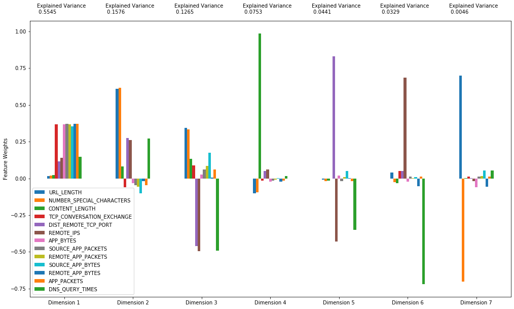

```python
results = pca_results(data_nonulls_only_numerical, pca)
```

```python
results.cumsum()
```

|  | Explained Variance | URL_LENGTH | NUMBER_SPECIAL_CHARACTERS | CONTENT_LENGTH | TCP_CONVERSATION_EXCHANGE | DIST_REMOTE_TCP_PORT | REMOTE_IPS | APP_BYTES | SOURCE_APP_PACKETS | REMOTE_APP_PACKETS | SOURCE_APP_BYTES | REMOTE_APP_BYTES | APP_PACKETS | DNS_QUERY_TIMES |
| --- | --- | --- | --- | --- | --- | --- | --- | --- | --- | --- | --- | --- | --- | --- |
| Dimension 1 | 0.5545 | 0.0171 | 0.0182 | 0.0229 | 0.3681 | 0.1162 | 0.1416 | 0.3692 | 0.3700 | 0.3679 | 0.3551 | 0.3696 | 0.3700 | 0.1470 |
| Dimension 2 | 0.7121 | 0.6279 | 0.6339 | 0.1052 | 0.3088 | 0.3908 | 0.4033 | 0.3366 | 0.3248 | 0.3106 | 0.2516 | 0.3497 | 0.3248 | 0.4191 |
| Dimension 3 | 0.8386 | 0.9705 | 0.9664 | 0.2380 | 0.3958 | -0.0695 | -0.0931 | 0.3621 | 0.3866 | 0.3951 | 0.4253 | 0.3533 | 0.3866 | -0.0738 |
| Dimension 4 | 0.9139 | 0.8697 | 0.8731 | 1.2243 | 0.3795 | -0.0180 | -0.0317 | 0.3398 | 0.3713 | 0.3856 | 0.4281 | 0.3319 | 0.3713 | -0.0598 |
| Dimension 5 | 0.9580 | 0.8628 | 0.8555 | 1.2101 | 0.3792 | 0.8129 | -0.4601 | 0.3594 | 0.3540 | 0.3936 | 0.4783 | 0.3348 | 0.3540 | -0.4091 |
| Dimension 6 | 0.9909 | 0.9029 | 0.8307 | 1.1763 | 0.4276 | 0.8631 | 0.2248 | 0.3365 | 0.3668 | 0.3966 | 0.4887 | 0.2807 | 0.3668 | -1.1294 |
| Dimension 7 | 0.9955 | 1.6036 | 0.1270 | 1.1796 | 0.4382 | 0.8656 | 0.2057 | 0.2746 | 0.3802 | 0.4125 | 0.5422 | 0.2253 | 0.3802 | -1.0761 |

##### Explanation:

There are many features in the dataset so I decided to use n_components of 7. This reduces the dimensions of the data down to 7. The number of dimensions should always be less than the original number of dimensions.

I then created plot that shows each of 7 principle components extracted, and how related each of the original variables is to that principle components. In other words, the plot shows how each of the components relate to each of the variables. I analyzed each of the dimensions below. I also used cumsum to display the cumulative sum for each dimension.

**Dimension 1**: This first dimension explains 0.5545, or 55.45 percent, of the overall variance.

```
- Most of the features have equal importance. Specifically, the features TCP_CONVERSATION_EXCHANGE, APP_BYTES, SOURCE_APP_PACKETS, REMOTE_APP_PACKETS, SOURCE_APP_BYTES, REMOTE_APP_BYTES, and APP_PACKETS are most highly correlated.
```

**Dimension 2**: This dimension explains 0.1576, or 15.76 percent, of the overall variance.

```
- URL_LENGTH and NUMBER_SPECIAL_CHARACTERS are most highly correlated in this dimension.
```

**Dimension 3**: This dimension explains 0.1265, or 12.65 percent, of the overall variance.

```
- URL LENGTH and NUMBER_SPECIAL_CHARACTERS are positively correlated in this dimension, and  REMOTE_IPS and DNS_QUERY_TIMES is negatively correlated.
```

**Dimension 4**: This dimension explains 0.0753, or 7.53 percent, of the overall variance.

```
- In dimension 4 CONTENT_LENGTH is highly correlated. This feature has significantly more importance than other features in this dimension.
```

**Dimension 5**: This dimension explains 0.0441, or 4.41 percent, of the overall variance.

```
- DIST_REMOTE_TCP_PORT is highly positively correlated in this dimension.
```

**Dimension 6**: This dimension explains 0.0329, or 3.29 percent, of the overall variance.

```
- REMOTE_IPS is highly positively correlated in this dimension, and DNS_QUERY_TIMES is highly negatively correlated.
```

**Dimension 7**: This dimension explains 0.0046, or 0.46 percent, of the overall variance.

```
- URL_LENGTH feature is highly positively correlated in this dimension, and the NUMBER_SPECIAL_CHARACTERS feature is highly negatively correlated.
```

### c) Report the optimal number of reduced dimensions based on a scree plot (2 points). Explain and justify your choice.

- look at elbow

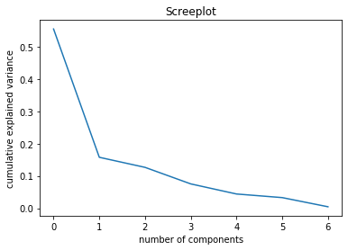

```python
plt.plot(pca.explained_variance_ratio_)
plt.xlabel('number of components')
plt.ylabel('cumulative explained variance')
plt.title("Screeplot")
plt.show()
```

##### Explanation:

A screeplot uses PCA components to find the component giving the last substantial drop in variance. This is a point of inflection, and it is where you can see an elbow on the graph. In other words, when examining the graph you should look for where there is a shift to a much shallower angle. The point of inflection looks to be 1 on the screeplot. This means 1 should be used as the principle components because there is a bend at this number on the graph. Therefore, the optimal number of dimensions is 1 based on this screeplot.

```python
pca_new = PCA(n_components=1).fit(data_nonulls_only_numerical)
pca_samples = pca_new.transform(data_nonulls_only_numerical)
```

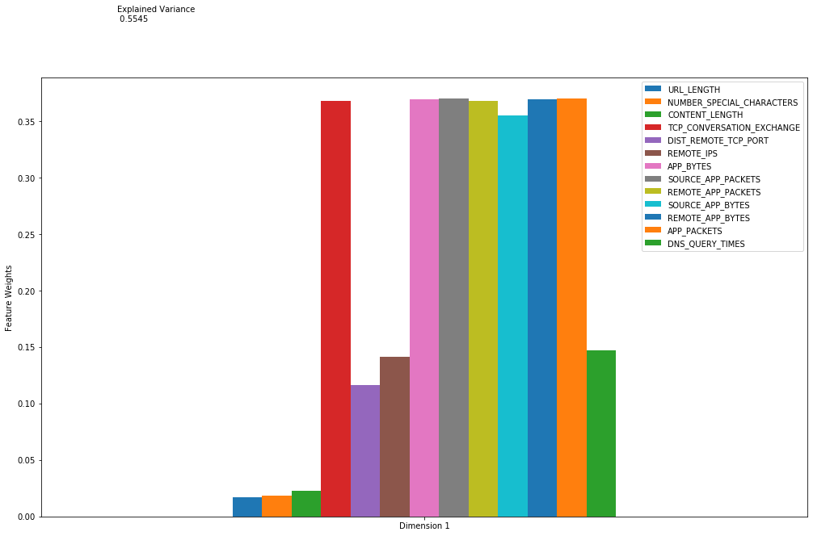

```python
pca_results_2 = pca_results(data_nonulls_only_numerical, pca_new)
```

```python
pca_results_2.cumsum()
```

|  | Explained Variance | URL_LENGTH | NUMBER_SPECIAL_CHARACTERS | CONTENT_LENGTH | TCP_CONVERSATION_EXCHANGE | DIST_REMOTE_TCP_PORT | REMOTE_IPS | APP_BYTES | SOURCE_APP_PACKETS | REMOTE_APP_PACKETS | SOURCE_APP_BYTES | REMOTE_APP_BYTES | APP_PACKETS | DNS_QUERY_TIMES |
| --- | --- | --- | --- | --- | --- | --- | --- | --- | --- | --- | --- | --- | --- | --- |
| Dimension 1 | 0.5545 | 0.0171 | 0.0182 | 0.0229 | 0.3681 | 0.1162 | 0.1416 | 0.3692 | 0.37 | 0.3679 | 0.3551 | 0.3696 | 0.37 | 0.147 |

##### Explanation:

When using only one dimension, setting n_components = 1, 55.45 percent of the overall variance is explained by this dimension. In this dimension many of the features appear to have equal importance. For example, TCP_CONVERSATION_EXCHANGE, APP_BYTES, SOURCE_APP_PACKETS, REMOTE_APP_PACKETS, SOURCE_APP_BYTES, REMOTE_APP_BYTES, and APP_PACKETS are all very highly correlated and have relatively high and similar feature weight.

### d) Use t-SNE to create a visualization of the malicious and benign websites in 2-D space (3 points). Tune your perplexity and iterations to get the "best" results.

NOTE: Read more about tuning t-SNE here: https://distill.pub/2016/misread-tsne/

- use t-SNE in 2-D space
- Tune your perplexity and iterations to get the "best" results.: perplexity here refers to weighting of do you do a better job of making tight clusters tighter or separating out clusters in 2-D space. Which one will you spend time on? make things far apart or make clusters tighter
- **never set perplexity** higher than the number of variables you have
- Algorithm requires more iterations

```python
target = 'Type'

X = data_nonulls_only_numerical
target_y = data_nonulls_only_numerical_not_scaled[target].values
```

#### 1) Plot TSNE without tuning parameters (2pts)

```python
tsne = TSNE(n_components=2, random_state= 0)

X_2d = tsne.fit_transform(X)
out = []
for i,(x,y) in enumerate(X_2d):
    out.append((target_y[i],x,y))
df = pd.DataFrame(out,columns=['Type','x','y'])
```

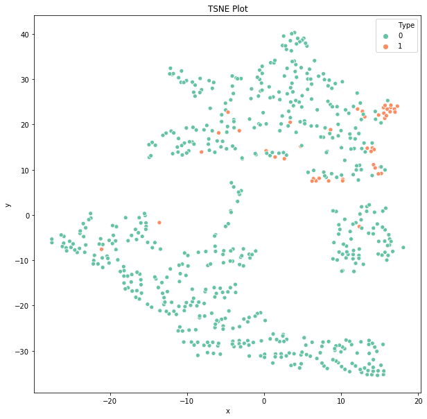

```python
plt.figure(figsize=(10,10))
sns.scatterplot(data=df,x='x',y='y',hue='Type',legend='full',palette='Set2').set_title("TSNE Plot")
plt.show()
```

#### 2) Try different combinations of perplexity and number of iterations, and compare visualization results (1pt)

```python
perplexity = 50#10- weird 1000- awful #50
n_iter = 10000#10000 #500 #number of iterations #assigning position of points so they can form t-dstribution 10- times
tsne = TSNE(n_components=2,
            perplexity = perplexity,
            n_iter = n_iter,
            random_state=3)#0)
X_2d = tsne.fit_transform(X)
out = []
for i,(x,y) in enumerate(X_2d):
    out.append((target_y[i],x,y))
df = pd.DataFrame(out,columns=['Type','x','y'])
```

```python
#df
```

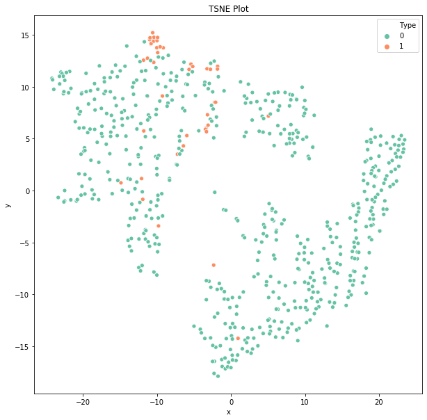

```python
plt.figure(figsize=(10,10))
sns.scatterplot(data=df,x='x',y='y',hue='Type',legend='full',palette='Set2').set_title("TSNE Plot")
plt.show()
```

##### Explanation:

In the code of above I changed the perplexity to 50 and set the n_iter, number of iterations, to 10,000. This plot is not as good as the plot I created below. The orange points, that have a Type of 1 which indicates they are malicious websites, is spread out along the y- axis throughout the graph. Therefore, they are not tighly clustered together, and they are not far away from the green points. As well, benign websites, green points are spread out throughout the graph and are not clustered together.

```python
perplexity = 20#10- weird 1000- awful #50
n_iter = 500#10000 #500 #number of iterations #assigning position of points so they can form t-dstribution 10- times
tsne = TSNE(n_components=2,
            perplexity = perplexity,
            n_iter = n_iter,
            random_state=3)#0)
X_2d = tsne.fit_transform(X)
out = []
for i,(x,y) in enumerate(X_2d):
    out.append((target_y[i],x,y))
df = pd.DataFrame(out,columns=['Type','x','y'])
```

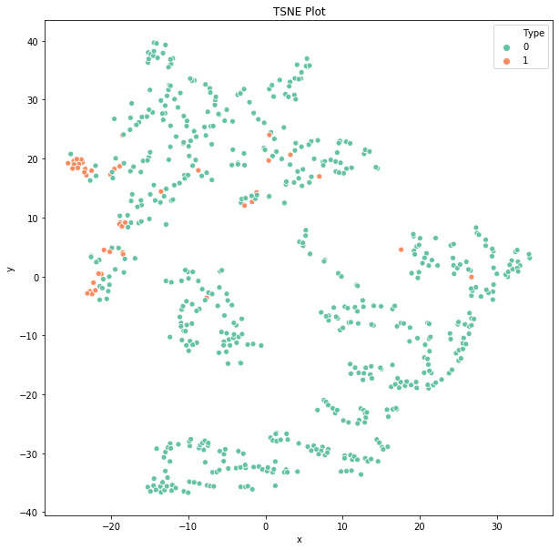

```python
plt.figure(figsize=(10,10))
sns.scatterplot(data=df,x='x',y='y',hue='Type',legend='full',palette='Set2').set_title("TSNE Plot")
plt.show()
```

##### Explanation:

In the code above I change the perplexity to 20, and the number of iterations, n_iter, to 500. By reducing both the perplexity and number of iterations I created a better visualization than the plot created above. The malicious websites which are the orange points, they are type 1, are plotted in the same general area and are closer together. The benign websites, green points with a type of 0, are spread out throughout the graph; although, within the graph there are smaller clusters of green points. This indicates that there are non-malicious websites that have similar features because they are clustered together and away from other green points.

### e) Bonus (max 2 points): Use Bokeh to create an interactive visualization (e.g. using hover) to allow users to explore your t-SNE results. Report an interesting finding about the data from your visualization.

```python
from bokeh.plotting import figure #will chart data
import numpy as np
import pandas as pd
from bokeh.io import show, output_notebook
from bokeh.models.tools import HoverTool
```

```python
output_notebook()
```

```python
perplexity = 20#10- weird 1000- awful #50
n_iter = 500#10000 #500 #number of iterations #assigning position of points so they can form t-dstribution 10- times
tsne = TSNE(n_components=2,
            perplexity = perplexity,
            n_iter = n_iter,
            random_state=3)#0)
X_2d = tsne.fit_transform(X)
out = []
for i,(x,y) in enumerate(X_2d):
    out.append((target_y[i],x,y))
df = pd.DataFrame(out,columns=['type','x','y'])
```

```python
df.head(5)
```

[output not shown]

```python
select_tools = ['box_select', 'lasso_select', 'poly_select', 'tap', 'reset']

# Create the figure
fig = figure(plot_height=800,
             plot_width=800,
             x_axis_label='x',
             y_axis_label='y',
             title='TSNE Plot of Malicious Versus Benign Websites when Perplexity is 20 and n_iter is 500',
             toolbar_location='below', #tool bar will be at the bottom of the figure
             tools=select_tools)
```

```python
fig.circle('x', 'y', source=df[df.type==0],color='red', size=7,legend="Benign Website (Type 0)")
fig.circle('x', 'y', source=df[df.type==1],color='blue', size=7,legend="Malicious Website (Type 1)")

tooltips = [
            ('type','@type'), #label and notation to show us label we want begins with @ ; label onto the value column
            ('x', '@x'),
            ('y', '@y')
           ]
fig.add_tools(HoverTool(tooltips=tooltips))
show(fig)
```

[interactive chart not shown]

##### Explanation:

There are way less Malicious Websites in the DataFrame then Benign Websites. This plot allows me to better understand the points because I can view the x and y axis numbers with the hover tool. One interesting finding I discovered with this graph is that the blue point furthest on the x-axis is actually two points. If you hover over the blue dot you get two legends. This means that there is another point the blue dot is covering. This second point is otherwise invisable to the eye without the hovertool. The X-axis of these two points are 26.709 and 26.707. The y axis of the points are -0.117 and -0.115. The type of both points is 1, indicating that they are malicious websites.